# Elsevier 2022 SDG mapping

# General to all SDGs

## Introduction

The United Nations Sustainable Development Goals (SDGs) challenge the global community to build a world where no one is left behind.

Since 2018, Elsevier has generated SDG search queries to help researchers and institutions track and demonstrate progress toward the SDG targets. In the past 3 years, these queries, along with the university’s own data and evidence supporting progress and contributions to the particular SDG outside of research-based metrics, are used for the THE Impact Rankings.

## Method

For 2022, this SDG uses the exact same search query and ML algorithm as the Elsevier 2021 SDG mapping. [Full details of the 2021 methodology are available on Digital Commons Data.](https://elsevier.digitalcommonsdata.com/datasets/9sxdykm8s4/4)

# [SDG 6 - Ensure availability and sustainable management of water and sanitation for all](https://sdgs.un.org/goals/goal6)

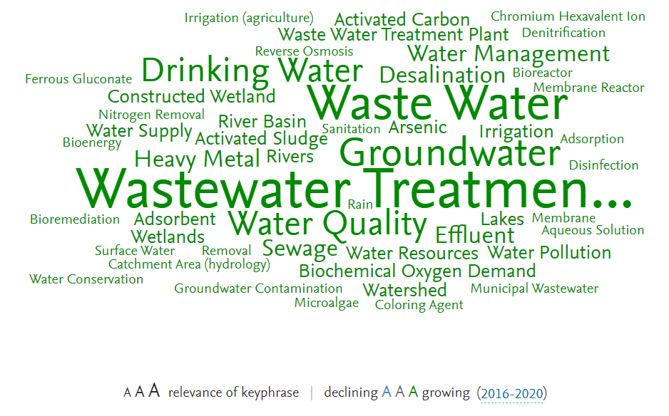

Explore this wordcloud plus the most active contributors on the [SciVal SDG site](https://scival.com/sdg)

## Query

Below is the full search query used for this SDG. We’ve broken it down by each query component. Use the + and – to concatenate the different bracket levels.

(

(

TITLE-ABS

(

"riparian zone restoration"

)

OR AUTHKEY

(

"riparian zone restoration"

)

OR

(

(

TITLE-ABS("lakes") OR TITLE-ABS("lake")

)

AND TITLE-ABS

(

"ecosystem rehabilitation"

)

)

OR

(

(

AUTHKEY("lakes") OR AUTHKEY("lake")

)

AND AUTHKEY

(

"ecosystem rehabilitation"

)

)

OR

(

TITLE-ABS

(

"rehabilitation of water ecosystem"

)

OR TITLE-ABS

(

"rehabilitation of water ecosystems"

)

OR TITLE-ABS

(

"rehabilitation of the water ecosystem"

)

OR TITLE-ABS

(

"rehabilitation of the water ecosystems"

)

OR TITLE-ABS

(

"rehabilitate water ecosystem"

)

OR TITLE-ABS

(

"rehabilitate water ecosystems"

)

OR TITLE-ABS

(

"rehabilitate the water ecosystem"

)

OR TITLE-ABS

(

"rehabilitate the water ecosystems"

)

OR TITLE-ABS

(

"water ecosystem rehabilitation"

)

OR TITLE-ABS

(

"water ecosystems rehabilitation"

)

)

OR

(

AUTHKEY

(

"rehabilitation of water ecosystem"

)

OR AUTHKEY

(

"rehabilitation of water ecosystems"

)

OR AUTHKEY

(

"rehabilitation of the water ecosystem"

)

OR AUTHKEY

(

"rehabilitation of the water ecosystems"

)

OR AUTHKEY

(

"rehabilitate water ecosystem"

)

OR AUTHKEY

(

"rehabilitate water ecosystems"

)

OR AUTHKEY

(

"rehabilitate the water ecosystem"

)

OR AUTHKEY

(

"rehabilitate the water ecosystems"

)

OR AUTHKEY

(

"water ecosystem rehabilitation"

)

OR AUTHKEY

(

"water ecosystems rehabilitation"

)

)

OR

(

TITLE-ABS

(

"preservation of rivers"

)

OR TITLE-ABS

(

"preservation of river"

)

OR TITLE-ABS

(

"preserve rivers"

)

OR TITLE-ABS

(

"preserve river"

)

OR TITLE-ABS

(

"river preservation"

)

OR TITLE-ABS

(

"rivers preservation"

)

)

OR

(

AUTHKEY

(

"preservation of rivers"

)

OR AUTHKEY

(

"preservation of river"

)

OR AUTHKEY

(

"preserve rivers"

)

OR AUTHKEY

(

"preserve river"

)

OR AUTHKEY

(

"river preservation"

)

OR AUTHKEY

(

"rivers preservation"

)

)

OR

(

TITLE-ABS

(

"protection of lake"

)

OR TITLE-ABS

(

"protection of lakes"

)

OR TITLE-ABS

(

"protection of the lake"

)

OR TITLE-ABS

(

"protection of the lakes"

)

OR TITLE-ABS

(

"protect lake"

)

OR TITLE-ABS

(

"protect lakes"

)

OR TITLE-ABS

(

"protect the lake"

)

OR TITLE-ABS

(

"protect the lakes"

)

OR TITLE-ABS

(

"lake protection"

)

OR TITLE-ABS

(

"lakes protection"

)

)

OR

(

AUTHKEY

(

"protection of lake"

)

OR AUTHKEY

(

"protection of lakes"

)

OR AUTHKEY

(

"protection of the lake"

)

OR AUTHKEY

(

"protection of the lakes"

)

OR AUTHKEY

(

"protect lake"

)

OR AUTHKEY

(

"protect lakes"

)

OR AUTHKEY

(

"protect the lake"

)

OR AUTHKEY

(

"protect the lakes"

)

OR AUTHKEY

(

"lake protection"

)

OR AUTHKEY

(

"lakes protection"

)

)

OR

(

TITLE-ABS

(

"river"

)

AND TITLE-ABS

(

"protect"

)

AND TITLE-ABS

(

"restore"

)

)

OR

(

AUTHKEY

(

"river"

)

AND AUTHKEY

(

"protect"

)

AND AUTHKEY

(

"restore"

)

)

OR

(

TITLE-ABS

(

"lake restoration"

)

OR TITLE-ABS

(

"lakes restoration"

)

OR TITLE-ABS

(

" restoration of lake"

)

OR TITLE-ABS

(

"restoration of lakes"

)

OR TITLE-ABS

(

"restoration of the lake"

)

OR TITLE-ABS

(

"restoration of the lakes"

)

OR TITLE-ABS

(

"restore lake"

)

OR TITLE-ABS

(

"restore lakes"

)

OR TITLE-ABS

(

"restore the lake"

)

OR TITLE-ABS

(

"restore the lakes"

)

)

OR

(

AUTHKEY

(

"lake restoration"

)

OR AUTHKEY

(

"lakes restoration"

)

OR AUTHKEY

(

" restoration of lake"

)

OR AUTHKEY

(

"restoration of lakes"

)

OR AUTHKEY

(

"restoration of the lake"

)

OR AUTHKEY

(

"restoration of the lakes"

)

OR AUTHKEY

(

"restore lake"

)

OR AUTHKEY

(

"restore lakes"

)

OR AUTHKEY

(

"restore the lake"

)

OR AUTHKEY

(

"restore the lakes"

)

)

OR

(

TITLE-ABS

(

"river"

)

AND TITLE-ABS

(

"rehabilitation"

)

)

OR

(

AUTHKEY

(

"river"

)

AND AUTHKEY

(

"rehabilitation"

)

)

OR

(

(

TITLE-ABS("protection of groundwater") OR TITLE-ABS("protection of groundwaters") OR TITLE-ABS("protect groundwater") OR TITLE-ABS("protect groundwaters") OR TITLE-ABS("groundwater protection") OR TITLE-ABS("groundwaters protection") OR TITLE-ABS("protection of ground-water") OR TITLE-ABS("protection of ground-waters") OR TITLE-ABS("protect ground-water") OR TITLE-ABS("protect ground-waters") OR TITLE-ABS("ground-water protection") OR TITLE-ABS("ground-waters protection")

)

OR

(

TITLE-ABS("protection of groundwater") OR TITLE-ABS("protection of groundwaters") OR TITLE-ABS("protect groundwater") OR TITLE-ABS("protect groundwaters") OR TITLE-ABS("groundwater protection") OR TITLE-ABS("groundwaters protection") OR TITLE-ABS("protection of groundwater") OR TITLE-ABS("protection of groundwaters") OR TITLE-ABS("protect groundwater") OR TITLE-ABS("protect groundwaters") OR TITLE-ABS("groundwater protection") OR TITLE-ABS("groundwaters protection")

)

)

OR

(

(

AUTHKEY("protection of groundwater") OR AUTHKEY("protection of groundwaters") OR AUTHKEY("protect groundwater") OR AUTHKEY("protect groundwaters") OR AUTHKEY("groundwater protection") OR AUTHKEY("groundwaters protection") OR AUTHKEY("protection of ground-water") OR AUTHKEY("protection of ground-waters") OR AUTHKEY("protect ground-water") OR AUTHKEY("protect ground-waters") OR AUTHKEY("ground-water protection") OR AUTHKEY("ground-waters protection")

)

OR

(

AUTHKEY("protection of groundwater") OR AUTHKEY("protection of groundwaters") OR AUTHKEY("protect groundwater") OR AUTHKEY("protect groundwaters") OR AUTHKEY("groundwater protection") OR AUTHKEY("groundwaters protection") OR AUTHKEY("protection of groundwater") OR AUTHKEY("protection of groundwaters") OR AUTHKEY("protect groundwater") OR AUTHKEY("protect groundwaters") OR AUTHKEY("groundwater protection") OR AUTHKEY("groundwaters protection")

)

)

OR TITLE-ABS

(

"stabilization of streams"

)

OR AUTHKEY

(

"stabilization of streams"

)

OR

(

(

TITLE-ABS("lakes") OR TITLE-ABS("rivers") OR TITLE-ABS("aquifers")

)

AND TITLE-ABS

(

"Resource protection"

)

)

OR

(

(

AUTHKEY("lakes") OR AUTHKEY("rivers") OR AUTHKEY("aquifers")

)

AND AUTHKEY

(

"Resource protection"

)

)

OR

(

TITLE-ABS

(

"water ecosystems"

)

AND TITLE-ABS

(

"protection of"

)

)

OR

(

AUTHKEY

(

"water ecosystems"

)

AND AUTHKEY

(

"protection of"

)

)

OR

(

TITLE-ABS

(

"river"

)

AND TITLE-ABS

(

"protection"

)

AND TITLE-ABS

(

"restoration"

)

)

OR

(

AUTHKEY

(

"river"

)

AND AUTHKEY

(

"protection"

)

AND AUTHKEY

(

"restoration"

)

)

OR

(

TITLE-ABS

(

"rivers"

)

AND TITLE-ABS

(

"protect"

)

AND TITLE-ABS

(

"restore"

)

)

OR

(

AUTHKEY

(

"rivers"

)

AND AUTHKEY

(

"protect"

)

AND AUTHKEY

(

"restore"

)

)

OR

(

TITLE-ABS

(

"rehabilitation of lake"

)

OR TITLE-ABS

(

"rehabilitation of lakes"

)

OR TITLE-ABS

(

"rehabilitation of the lake"

)

OR TITLE-ABS

(

"rehabilitation of the lakes"

)

OR TITLE-ABS

(

"lake rehabilitation"

)

OR TITLE-ABS

(

"lakes rehabilitation"

)

OR TITLE-ABS

(

"rehabilitate lake"

)

OR TITLE-ABS

(

"rehabilitate lakes"

)

OR TITLE-ABS

(

"rehabilitate the lake"

)

OR TITLE-ABS

(

"rehabilitate the lakes"

)

)

OR

(

AUTHKEY

(

"rehabilitation of lake"

)

OR AUTHKEY

(

"rehabilitation of lakes"

)

OR AUTHKEY

(

"rehabilitation of the lake"

)

OR AUTHKEY

(

"rehabilitation of the lakes"

)

OR AUTHKEY

(

"lake rehabilitation"

)

OR AUTHKEY

(

"lakes rehabilitation"

)

OR AUTHKEY

(

"rehabilitate lake"

)

OR AUTHKEY

(

"rehabilitate lakes"

)

OR AUTHKEY

(

"rehabilitate the lake"

)

OR AUTHKEY

(

"rehabilitate the lakes"

)

)

OR

(

TITLE-ABS

(

"rehabilitation of river"

)

OR TITLE-ABS

(

"rehabilitation of rivers"

)

OR TITLE-ABS

(

"rehabilitation of the river"

)

OR TITLE-ABS

(

"rehabilitation of the rivers"

)

OR TITLE-ABS

(

"river rehabilitation"

)

OR TITLE-ABS

(

"rivers rehabilitation"

)

OR TITLE-ABS

(

"river bank rehabilitation"

)

OR TITLE-ABS

(

"river banks rehabilitation"

)

OR TITLE-ABS

(

"rehabilitate river"

)

OR TITLE-ABS

(

"rehabilitate rivers"

)

OR TITLE-ABS

(

"rehabilitate the river"

)

OR TITLE-ABS

(

"rehabilitate the rivers"

)

)

OR

(

AUTHKEY

(

"rehabilitation of river"

)

OR AUTHKEY

(

"rehabilitation of rivers"

)

OR AUTHKEY

(

"rehabilitation of the river"

)

OR AUTHKEY

(

"rehabilitation of the rivers"

)

OR AUTHKEY

(

"river rehabilitation"

)

OR AUTHKEY

(

"rivers rehabilitation"

)

OR AUTHKEY

(

"river bank rehabilitation"

)

OR AUTHKEY

(

"river banks rehabilitation"

)

OR AUTHKEY

(

"rehabilitate river"

)

OR AUTHKEY

(

"rehabilitate rivers"

)

OR AUTHKEY

(

"rehabilitate the river"

)

OR AUTHKEY

(

"rehabilitate the rivers"

)

)

OR TITLE-ABS

(

"river degradation"

)

OR AUTHKEY

(

"river degradation"

)

OR

(

(

TITLE-ABS("rehabilitation*") OR TITLE-ABS("restoration*")

)

AND

(

TITLE-ABS("water") OR TITLE-ABS("lake*") OR TITLE-ABS("river*") OR TITLE-ABS("basin*") OR TITLE-ABS("estuar*")

)

AND TITLE-ABS

(

"ecosystem*"

)

)

OR

(

(

AUTHKEY("rehabilitation*") OR AUTHKEY("restoration*")

)

AND

(

AUTHKEY("water") OR AUTHKEY("lake*") OR AUTHKEY("river*") OR AUTHKEY("basin*") OR AUTHKEY("estuar*")

)

AND AUTHKEY

(

"ecosystem*"

)

)

OR

(

(

TITLE-ABS("rehabilitation") OR TITLE-ABS("restoration")

)

AND TITLE-ABS

(

"water bodies"

)

)

OR

(

(

AUTHKEY("rehabilitation") OR AUTHKEY("restoration")

)

AND AUTHKEY

(

"water bodies"

)

)

OR

(

(

TITLE-ABS("protect*") OR TITLE-ABS("conservation*")

)

AND TITLE-ABS

(

"water*"

)

AND TITLE-ABS

(

"ecosystem*"

)

)

OR

(

(

AUTHKEY("protect*") OR AUTHKEY("conservation*")

)

AND AUTHKEY

(

"water*"

)

AND AUTHKEY

(

"ecosystem*"

)

)

OR

(

TITLE-ABS

(

"restoration of stream"

)

OR TITLE-ABS

(

"restoration of streams"

)

OR TITLE-ABS

(

"restoration of the stream"

)

OR TITLE-ABS

(

"restoration of the streams"

)

OR TITLE-ABS

(

"restore stream"

)

OR TITLE-ABS

(

"restore streams"

)

OR TITLE-ABS

(

"restore the streams"

)

OR TITLE-ABS

(

"restore the stream"

)

OR TITLE-ABS

(

"stream restoration"

)

OR TITLE-ABS

(

"streams restoration"

)

OR TITLE-ABS

(

"river stream restoration"

)

OR TITLE-ABS

(

"river streams restoration"

)

)

OR

(

AUTHKEY

(

"restoration of stream"

)

OR AUTHKEY

(

"restoration of streams"

)

OR AUTHKEY

(

"restoration of the stream"

)

OR AUTHKEY

(

"restoration of the streams"

)

OR AUTHKEY

(

"restore stream"

)

OR AUTHKEY

(

"restore streams"

)

OR AUTHKEY

(

"restore the streams"

)

OR AUTHKEY

(

"restore the stream"

)

OR AUTHKEY

(

"stream restoration"

)

OR AUTHKEY

(

"streams restoration"

)

OR AUTHKEY

(

"river stream restoration"

)

OR AUTHKEY

(

"river streams restoration"

)

)

OR

(

(

TITLE-ABS("wetlands") OR TITLE-ABS("wetland")

)

AND TITLE-ABS

(

"restoration and management"

)

)

OR

(

(

AUTHKEY("wetlands") OR AUTHKEY("wetland")

)

AND AUTHKEY

(

"restoration and management"

)

)

OR TITLE-ABS

(

"protecting freshwaters"

)

OR AUTHKEY

(

"protecting freshwaters"

)

OR TITLE-ABS

(

"degraded river"

)

OR AUTHKEY

(

"degraded river"

)

OR

(

(

TITLE-ABS("rehabilitation*") OR TITLE-ABS("restoration*")

)

AND

(

TITLE-ABS("lake*") OR TITLE-ABS("river*") OR TITLE-ABS("basin*") OR TITLE-ABS("estuar*")

)

)

OR

(

(

AUTHKEY("rehabilitation*") OR AUTHKEY("restoration*")

)

AND

(

AUTHKEY("lake*") OR AUTHKEY("river*") OR AUTHKEY("basin*") OR AUTHKEY("estuar*")

)

)

OR

(

(

(TITLE-ABS("water ecosystems") OR TITLE-ABS("water eco-systems") OR TITLE-ABS("water ecosystem") OR TITLE-ABS("water eco-system")) AND TITLE-ABS("preservation")

)

OR

(

(TITLE-ABS("water ecosystems") OR TITLE-ABS("water ecosystems") OR TITLE-ABS("water ecosystem") OR TITLE-ABS("water ecosystem")) AND TITLE-ABS("preservation")

)

)

OR

(

(

(AUTHKEY("water ecosystems") OR AUTHKEY("water eco-systems") OR AUTHKEY("water ecosystem") OR AUTHKEY("water eco-system")) AND AUTHKEY("preservation")

)

OR

(

(AUTHKEY("water ecosystems") OR AUTHKEY("water ecosystems") OR AUTHKEY("water ecosystem") OR AUTHKEY("water ecosystem")) AND AUTHKEY("preservation")

)

)

OR

(

TITLE-ABS

(

"restoration of Streambank"

)

OR TITLE-ABS

(

"restoration of Streambanks"

)

OR TITLE-ABS

(

"restore Streambank"

)

OR TITLE-ABS

(

"restore Streambanks"

)

OR TITLE-ABS

(

"Streambank restoration"

)

OR TITLE-ABS

(

"Streambanks restoration"

)

)

OR

(

AUTHKEY

(

"restoration of Streambank"

)

OR AUTHKEY

(

"restoration of Streambanks"

)

OR AUTHKEY

(

"restore Streambank"

)

OR AUTHKEY

(

"restore Streambanks"

)

OR AUTHKEY

(

"Streambank restoration"

)

OR AUTHKEY

(

"Streambanks restoration"

)

)

OR

(

TITLE-ABS

(

"protection of water ecosystem"

)

OR TITLE-ABS

(

"protection of water ecosystems"

)

OR TITLE-ABS

(

"protection of the water ecosystem"

)

OR TITLE-ABS

(

"protection of the water ecosystems"

)

OR TITLE-ABS

(

"protect water ecosystem"

)

OR TITLE-ABS

(

"protect water ecosystems"

)

OR TITLE-ABS

(

"protect the water ecosystem"

)

OR TITLE-ABS

(

"protect the water ecosystems"

)

OR TITLE-ABS

(

"water ecosystem protection"

)

OR TITLE-ABS

(

"water ecosystems protection"

)

)

OR

(

AUTHKEY

(

"protection of water ecosystem"

)

OR AUTHKEY

(

"protection of water ecosystems"

)

OR AUTHKEY

(

"protection of the water ecosystem"

)

OR AUTHKEY

(

"protection of the water ecosystems"

)

OR AUTHKEY

(

"protect water ecosystem"

)

OR AUTHKEY

(

"protect water ecosystems"

)

OR AUTHKEY

(

"protect the water ecosystem"

)

OR AUTHKEY

(

"protect the water ecosystems"

)

OR AUTHKEY

(

"water ecosystem protection"

)

OR AUTHKEY

(

"water ecosystems protection"

)

)

OR

(

(

TITLE-ABS("rehabilitation of water eco-system") OR TITLE-ABS("rehabilitation of water eco-systems") OR TITLE-ABS("rehabilitation of the water eco-system") OR TITLE-ABS("rehabilitation of the water eco-systems") OR TITLE-ABS("rehabilitate water eco-system") OR TITLE-ABS("rehabilitate water eco-systems") OR TITLE-ABS("rehabilitate the water eco-system") OR TITLE-ABS("rehabilitate the water eco-systems") OR TITLE-ABS("water eco-system rehabilitation") OR TITLE-ABS("water eco-systems rehabilitation")

)

OR

(

TITLE-ABS("rehabilitation of water ecosystem") OR TITLE-ABS("rehabilitation of water ecosystems") OR TITLE-ABS("rehabilitation of the water ecosystem") OR TITLE-ABS("rehabilitation of the water ecosystems") OR TITLE-ABS("rehabilitate water ecosystem") OR TITLE-ABS("rehabilitate water ecosystems") OR TITLE-ABS("rehabilitate the water ecosystem") OR TITLE-ABS("rehabilitate the water ecosystems") OR TITLE-ABS("water ecosystem rehabilitation") OR TITLE-ABS("water ecosystems rehabilitation")

)

)

OR

(

(

AUTHKEY("rehabilitation of water eco-system") OR AUTHKEY("rehabilitation of water eco-systems") OR AUTHKEY("rehabilitation of the water eco-system") OR AUTHKEY("rehabilitation of the water eco-systems") OR AUTHKEY("rehabilitate water eco-system") OR AUTHKEY("rehabilitate water eco-systems") OR AUTHKEY("rehabilitate the water eco-system") OR AUTHKEY("rehabilitate the water eco-systems") OR AUTHKEY("water eco-system rehabilitation") OR AUTHKEY("water eco-systems rehabilitation")

)

OR

(

AUTHKEY("rehabilitation of water ecosystem") OR AUTHKEY("rehabilitation of water ecosystems") OR AUTHKEY("rehabilitation of the water ecosystem") OR AUTHKEY("rehabilitation of the water ecosystems") OR AUTHKEY("rehabilitate water ecosystem") OR AUTHKEY("rehabilitate water ecosystems") OR AUTHKEY("rehabilitate the water ecosystem") OR AUTHKEY("rehabilitate the water ecosystems") OR AUTHKEY("water ecosystem rehabilitation") OR AUTHKEY("water ecosystems rehabilitation")

)

)

OR

(

TITLE-ABS

(

"protection of river"

)

OR TITLE-ABS

(

"protection of rivers"

)

OR TITLE-ABS

(

"protection of the river"

)

OR TITLE-ABS

(

"protection of the rivers"

)

OR TITLE-ABS

(

"protect river"

)

OR TITLE-ABS

(

"protect rivers"

)

OR TITLE-ABS

(

"protect the river"

)

OR TITLE-ABS

(

"protect the rivers"

)

OR TITLE-ABS

(

"river protection"

)

OR TITLE-ABS

(

"rivers protection"

)

OR TITLE-ABS

(

"river bank protection"

)

OR TITLE-ABS

(

"river banks protection"

)

)

OR

(

AUTHKEY

(

"protection of river"

)

OR AUTHKEY

(

"protection of rivers"

)

OR AUTHKEY

(

"protection of the river"

)

OR AUTHKEY

(

"protection of the rivers"

)

OR AUTHKEY

(

"protect river"

)

OR AUTHKEY

(

"protect rivers"

)

OR AUTHKEY

(

"protect the river"

)

OR AUTHKEY

(

"protect the rivers"

)

OR AUTHKEY

(

"river protection"

)

OR AUTHKEY

(

"rivers protection"

)

OR AUTHKEY

(

"river bank protection"

)

OR AUTHKEY

(

"river banks protection"

)

)

OR

(

(

TITLE-ABS("rehabilitation of groundwater") OR TITLE-ABS("rehabilitation of groundwaters") OR TITLE-ABS("rehabilitate groundwater") OR TITLE-ABS("rehabilitate groundwaters") OR TITLE-ABS("groundwater rehabilitation") OR TITLE-ABS("groundwaters rehabilitation") OR TITLE-ABS("rehabilitation of ground-water") OR TITLE-ABS("rehabilitation of ground-waters") OR TITLE-ABS("rehabilitate ground-water") OR TITLE-ABS("rehabilitate ground-waters") OR TITLE-ABS("ground-water rehabilitation") OR TITLE-ABS("ground-waters rehabilitation")

)

OR

(

TITLE-ABS("rehabilitation of groundwater") OR TITLE-ABS("rehabilitation of groundwaters") OR TITLE-ABS("rehabilitate groundwater") OR TITLE-ABS("rehabilitate groundwaters") OR TITLE-ABS("groundwater rehabilitation") OR TITLE-ABS("groundwaters rehabilitation") OR TITLE-ABS("rehabilitation of groundwater") OR TITLE-ABS("rehabilitation of groundwaters") OR TITLE-ABS("rehabilitate groundwater") OR TITLE-ABS("rehabilitate groundwaters") OR TITLE-ABS("groundwater rehabilitation") OR TITLE-ABS("groundwaters rehabilitation")

)

)

OR

(

(

AUTHKEY("rehabilitation of groundwater") OR AUTHKEY("rehabilitation of groundwaters") OR AUTHKEY("rehabilitate groundwater") OR AUTHKEY("rehabilitate groundwaters") OR AUTHKEY("groundwater rehabilitation") OR AUTHKEY("groundwaters rehabilitation") OR AUTHKEY("rehabilitation of ground-water") OR AUTHKEY("rehabilitation of ground-waters") OR AUTHKEY("rehabilitate ground-water") OR AUTHKEY("rehabilitate ground-waters") OR AUTHKEY("ground-water rehabilitation") OR AUTHKEY("ground-waters rehabilitation")

)

OR

(

AUTHKEY("rehabilitation of groundwater") OR AUTHKEY("rehabilitation of groundwaters") OR AUTHKEY("rehabilitate groundwater") OR AUTHKEY("rehabilitate groundwaters") OR AUTHKEY("groundwater rehabilitation") OR AUTHKEY("groundwaters rehabilitation") OR AUTHKEY("rehabilitation of groundwater") OR AUTHKEY("rehabilitation of groundwaters") OR AUTHKEY("rehabilitate groundwater") OR AUTHKEY("rehabilitate groundwaters") OR AUTHKEY("groundwater rehabilitation") OR AUTHKEY("groundwaters rehabilitation")

)

)

OR

(

TITLE-ABS-KEY

(

"protection of pond"

)

OR TITLE-ABS-KEY

(

"protection of ponds"

)

OR TITLE-ABS-KEY

(

"protect pond"

)

OR TITLE-ABS-KEY

(

"protect ponds"

)

OR TITLE-ABS-KEY

(

"pond protection"

)

OR TITLE-ABS-KEY

(

"ponds protection"

)

OR TITLE-ABS-KEY

(

"rehabilitation of pond"

)

OR TITLE-ABS-KEY

(

"rehabilitation of ponds"

)

OR TITLE-ABS-KEY

(

"rehabilitate pond"

)

OR TITLE-ABS-KEY

(

"rehabilitate ponds"

)

OR TITLE-ABS-KEY

(

"pond rehabilitation"

)

OR TITLE-ABS-KEY

(

"ponds rehabilitation"

)

OR TITLE-ABS-KEY

(

"restoration of pond"

)

OR TITLE-ABS-KEY

(

"restoration of ponds"

)

OR TITLE-ABS-KEY

(

"restore pond"

)

OR TITLE-ABS-KEY

(

"restore ponds"

)

OR TITLE-ABS-KEY

(

"pond restoration"

)

OR TITLE-ABS-KEY

(

"ponds restoration"

)

)

OR TITLE-ABS

(

"degraded rivers"

)

OR AUTHKEY

(

"degraded rivers"

)

OR TITLE-ABS

(

"stabilization of rivers"

)

OR AUTHKEY

(

"stabilization of rivers"

)

OR

(

TITLE-ABS

(

"preservation of aquifers"

)

OR TITLE-ABS

(

"preservation of aquifers"

)

OR TITLE-ABS

(

"preserve aquifer"

)

OR TITLE-ABS

(

"preserve aquifers"

)

OR TITLE-ABS

(

"aquifer preservation"

)

OR TITLE-ABS

(

"aquifers preservation"

)

)

OR

(

AUTHKEY

(

"preservation of aquifers"

)

OR AUTHKEY

(

"preservation of aquifers"

)

OR AUTHKEY

(

"preserve aquifer"

)

OR AUTHKEY

(

"preserve aquifers"

)

OR AUTHKEY

(

"aquifer preservation"

)

OR AUTHKEY

(

"aquifers preservation"

)

)

OR

(

(

(TITLE-ABS("water ecosystems") OR TITLE-ABS("water eco-systems") OR TITLE-ABS("water ecosystem") OR TITLE-ABS("water eco-system")) AND TITLE-ABS("rehabilitation")

)

OR

(

(TITLE-ABS("water ecosystems") OR TITLE-ABS("water ecosystems") OR TITLE-ABS("water ecosystem") OR TITLE-ABS("water ecosystem")) AND TITLE-ABS("rehabilitation")

)

)

OR

(

(

(AUTHKEY("water ecosystems") OR AUTHKEY("water eco-systems") OR AUTHKEY("water ecosystem") OR AUTHKEY("water eco-system")) AND AUTHKEY("rehabilitation")

)

OR

(

(AUTHKEY("water ecosystems") OR AUTHKEY("water ecosystems") OR AUTHKEY("water ecosystem") OR AUTHKEY("water ecosystem")) AND AUTHKEY("rehabilitation")

)

)

OR

(

TITLE-ABS

(

"rehabilitation of stream"

)

OR TITLE-ABS

(

"rehabilitation of streams"

)

OR TITLE-ABS

(

"rehabilitation of the stream"

)

OR TITLE-ABS

(

"rehabilitation of the streams"

)

OR TITLE-ABS

(

"rehabilitate stream"

)

OR TITLE-ABS

(

"rehabilitate streams"

)

OR TITLE-ABS

(

"rehabilitate the streams"

)

OR TITLE-ABS

(

"rehabilitate the stream"

)

OR TITLE-ABS

(

"stream rehabilitation"

)

OR TITLE-ABS

(

"streams rehabilitation"

)

OR TITLE-ABS

(

"river stream rehabilitation"

)

OR TITLE-ABS

(

"river streams rehabilitation"

)

)

OR

(

AUTHKEY

(

"rehabilitation of stream"

)

OR AUTHKEY

(

"rehabilitation of streams"

)

OR AUTHKEY

(

"rehabilitation of the stream"

)

OR AUTHKEY

(

"rehabilitation of the streams"

)

OR AUTHKEY

(

"rehabilitate stream"

)

OR AUTHKEY

(

"rehabilitate streams"

)

OR AUTHKEY

(

"rehabilitate the streams"

)

OR AUTHKEY

(

"rehabilitate the stream"

)

OR AUTHKEY

(

"stream rehabilitation"

)

OR AUTHKEY

(

"streams rehabilitation"

)

OR AUTHKEY

(

"river stream rehabilitation"

)

OR AUTHKEY

(

"river streams rehabilitation"

)

)

OR

(

TITLE-ABS

(

"riparian"

)

AND TITLE-ABS

(

"rehabilitation"

)

)

OR

(

AUTHKEY

(

"riparian"

)

AND AUTHKEY

(

"rehabilitation"

)

)

OR

(

TITLE-ABS-KEY

(

"protection of aquifers"

)

OR TITLE-ABS-KEY

(

"protection of aquifers"

)

OR TITLE-ABS-KEY

(

"protection of the aquifer"

)

OR TITLE-ABS-KEY

(

"protection of the aquifers"

)

OR TITLE-ABS-KEY

(

"protect aquifer"

)

OR TITLE-ABS-KEY

(

"protect aquifers"

)

OR TITLE-ABS-KEY

(

"protect the aquifer"

)

OR TITLE-ABS-KEY

(

"protect the aquifers"

)

OR TITLE-ABS-KEY

(

"aquifer protection"

)

OR TITLE-ABS-KEY

(

"aquifers protection"

)

OR TITLE-ABS-KEY

(

"rehabilitation of aquifer"

)

OR TITLE-ABS-KEY

(

"rehabilitation of aquifers"

)

OR TITLE-ABS-KEY

(

"rehabilitation of the aquifer"

)

OR TITLE-ABS-KEY

(

"rehabilitation of the aquifers"

)

OR TITLE-ABS-KEY

(

"rehabilitate aquifer"

)

OR TITLE-ABS-KEY

(

"rehabilitate aquifers"

)

OR TITLE-ABS-KEY

(

"rehabilitate the aquifer"

)

OR TITLE-ABS-KEY

(

"rehabilitate the aquifers"

)

OR TITLE-ABS-KEY

(

"aquifer rehabilitation"

)

OR TITLE-ABS-KEY

(

"aquifers rehabilitation"

)

OR TITLE-ABS-KEY

(

"aquifer restoration"

)

OR TITLE-ABS-KEY

(

"aquifers restoration"

)

OR TITLE-ABS-KEY

(

" restoration of aquifer"

)

OR TITLE-ABS-KEY

(

"restoration of aquifers"

)

OR TITLE-ABS-KEY

(

"restoration of the aquifer"

)

OR TITLE-ABS-KEY

(

"restoration of the aquifers"

)

OR TITLE-ABS-KEY

(

"restore aquifer"

)

OR TITLE-ABS-KEY

(

"restore aquifers"

)

OR TITLE-ABS-KEY

(

"restore the aquifer"

)

OR TITLE-ABS-KEY

(

"restore the aquifers"

)

)

OR TITLE-ABS

(

"riparian restoration"

)

OR AUTHKEY

(

"riparian restoration"

)

OR TITLE-ABS

(

"stabilization of stream banks"

)

OR AUTHKEY

(

"stabilization of stream banks"

)

OR

(

(

TITLE-ABS("protection of water eco-system") OR TITLE-ABS("protection of water eco-systems") OR TITLE-ABS("protection of the water eco-system") OR TITLE-ABS("protection of the water eco-systems") OR TITLE-ABS("protect water eco-system") OR TITLE-ABS("protect water eco-systems") OR TITLE-ABS("protect the water eco-system") OR TITLE-ABS("protect the water eco-systems") OR TITLE-ABS("water eco-system protection") OR TITLE-ABS("water eco-systems protection")

)

OR

(

TITLE-ABS("protection of water ecosystem") OR TITLE-ABS("protection of water ecosystems") OR TITLE-ABS("protection of the water ecosystem") OR TITLE-ABS("protection of the water ecosystems") OR TITLE-ABS("protect water ecosystem") OR TITLE-ABS("protect water ecosystems") OR TITLE-ABS("protect the water ecosystem") OR TITLE-ABS("protect the water ecosystems") OR TITLE-ABS("water ecosystem protection") OR TITLE-ABS("water ecosystems protection")

)

)

OR

(

(

AUTHKEY("protection of water eco-system") OR AUTHKEY("protection of water eco-systems") OR AUTHKEY("protection of the water eco-system") OR AUTHKEY("protection of the water eco-systems") OR AUTHKEY("protect water eco-system") OR AUTHKEY("protect water eco-systems") OR AUTHKEY("protect the water eco-system") OR AUTHKEY("protect the water eco-systems") OR AUTHKEY("water eco-system protection") OR AUTHKEY("water eco-systems protection")

)

OR

(

AUTHKEY("protection of water ecosystem") OR AUTHKEY("protection of water ecosystems") OR AUTHKEY("protection of the water ecosystem") OR AUTHKEY("protection of the water ecosystems") OR AUTHKEY("protect water ecosystem") OR AUTHKEY("protect water ecosystems") OR AUTHKEY("protect the water ecosystem") OR AUTHKEY("protect the water ecosystems") OR AUTHKEY("water ecosystem protection") OR AUTHKEY("water ecosystems protection")

)

)

OR

(

TITLE-ABS

(

"river restoration"

)

OR TITLE-ABS

(

"rivers restoration"

)

OR TITLE-ABS

(

"river bank restoration"

)

OR TITLE-ABS

(

"river banks restoration"

)

OR TITLE-ABS

(

" restoration of river"

)

OR TITLE-ABS

(

"restoration of rivers"

)

OR TITLE-ABS

(

"restoration of the river"

)

OR TITLE-ABS

(

"restoration of the rivers"

)

OR TITLE-ABS

(

"restore river"

)

OR TITLE-ABS

(

"restore rivers"

)

OR TITLE-ABS

(

"restore the river"

)

OR TITLE-ABS

(

"restore the rivers"

)

)

OR

(

AUTHKEY

(

"river restoration"

)

OR AUTHKEY

(

"rivers restoration"

)

OR AUTHKEY

(

"river bank restoration"

)

OR AUTHKEY

(

"river banks restoration"

)

OR AUTHKEY

(

" restoration of river"

)

OR AUTHKEY

(

"restoration of rivers"

)

OR AUTHKEY

(

"restoration of the river"

)

OR AUTHKEY

(

"restoration of the rivers"

)

OR AUTHKEY

(

"restore river"

)

OR AUTHKEY

(

"restore rivers"

)

OR AUTHKEY

(

"restore the river"

)

OR AUTHKEY

(

"restore the rivers"

)

)

OR

(

TITLE-ABS

(

"protection of Streambank"

)

OR TITLE-ABS

(

"protection of Streambanks"

)

OR TITLE-ABS

(

"protect Streambank"

)

OR TITLE-ABS

(

"protect Streambanks"

)

OR TITLE-ABS

(

"Streambank protection"

)

OR TITLE-ABS

(

"Streambanks protection"

)

)

OR

(

AUTHKEY

(

"protection of Streambank"

)

OR AUTHKEY

(

"protection of Streambanks"

)

OR AUTHKEY

(

"protect Streambank"

)

OR AUTHKEY

(

"protect Streambanks"

)

OR AUTHKEY

(

"Streambank protection"

)

OR AUTHKEY

(

"Streambanks protection"

)

)

OR

(

(

(TITLE-ABS("water ecosystems") OR TITLE-ABS("water eco-systems") OR TITLE-ABS("water ecosystem") OR TITLE-ABS("water eco-system")) AND TITLE-ABS("protection")

)

OR

(

(TITLE-ABS("water ecosystems") OR TITLE-ABS("water ecosystems") OR TITLE-ABS("water ecosystem") OR TITLE-ABS("water ecosystem")) AND TITLE-ABS("protection")

)

)

OR

(

(

(AUTHKEY("water ecosystems") OR AUTHKEY("water eco-systems") OR AUTHKEY("water ecosystem") OR AUTHKEY("water eco-system")) AND AUTHKEY("protection")

)

OR

(

(AUTHKEY("water ecosystems") OR AUTHKEY("water ecosystems") OR AUTHKEY("water ecosystem") OR AUTHKEY("water ecosystem")) AND AUTHKEY("protection")

)

)

OR

(

(

TITLE-ABS("protect*") OR TITLE-ABS("conservation*")

)

AND

(

TITLE-ABS("water") OR TITLE-ABS("lake*") OR TITLE-ABS("river*") OR TITLE-ABS("basin*") OR TITLE-ABS("estuar*")

)

AND TITLE-ABS

(

"ecosystem*"

)

)

OR

(

(

AUTHKEY("protect*") OR AUTHKEY("conservation*")

)

AND

(

AUTHKEY("water") OR AUTHKEY("lake*") OR AUTHKEY("river*") OR AUTHKEY("basin*") OR AUTHKEY("estuar*")

)

AND AUTHKEY

(

"ecosystem*"

)

)

OR

(

TITLE-ABS

(

"preservation of wetlands"

)

OR TITLE-ABS

(

"preservation of wetland"

)

OR TITLE-ABS

(

"preserve wetlands"

)

OR TITLE-ABS

(

"preserve river"

)

OR TITLE-ABS

(

"wetland preservation"

)

OR TITLE-ABS

(

"wetlands preservation"

)

)

OR

(

AUTHKEY

(

"preservation of wetlands"

)

OR AUTHKEY

(

"preservation of wetland"

)

OR AUTHKEY

(

"preserve wetlands"

)

OR AUTHKEY

(

"preserve river"

)

OR AUTHKEY

(

"wetland preservation"

)

OR AUTHKEY

(

"wetlands preservation"

)

)

OR TITLE-ABS

(

"lake degradation"

)

OR AUTHKEY

(

"lake degradation"

)

OR

(

(

(TITLE-ABS("water ecosystems") OR TITLE-ABS("water eco-systems") OR TITLE-ABS("water ecosystem") OR TITLE-ABS("water eco-system")) AND TITLE-ABS("restoration")

)

OR

(

(TITLE-ABS("water ecosystems") OR TITLE-ABS("water ecosystems") OR TITLE-ABS("water ecosystem") OR TITLE-ABS("water ecosystem")) AND TITLE-ABS("restoration")

)

)

OR

(

(

(AUTHKEY("water ecosystems") OR AUTHKEY("water eco-systems") OR AUTHKEY("water ecosystem") OR AUTHKEY("water eco-system")) AND AUTHKEY("restoration")

)

OR

(

(AUTHKEY("water ecosystems") OR AUTHKEY("water ecosystems") OR AUTHKEY("water ecosystem") OR AUTHKEY("water ecosystem")) AND AUTHKEY("restoration")

)

)

OR

(

TITLE-ABS

(

"rivers"

)

AND TITLE-ABS

(

"rehabilitation"

)

)

OR

(

AUTHKEY

(

"rivers"

)

AND AUTHKEY

(

"rehabilitation"

)

)

OR

(

TITLE-ABS

(

"riparian"

)

AND TITLE-ABS

(

"protection"

)

)

OR

(

AUTHKEY

(

"riparian"

)

AND AUTHKEY

(

"protection"

)

)

OR

(

(

TITLE-ABS("lakes") OR TITLE-ABS("lake")

)

AND TITLE-ABS

(

"restoration and management"

)

)

OR

(

(

AUTHKEY("lakes") OR AUTHKEY("lake")

)

AND AUTHKEY

(

"restoration and management"

)

)

OR TITLE-ABS

(

"riparian rehabilitation"

)

OR AUTHKEY

(

"riparian rehabilitation"

)

OR

(

(

TITLE-ABS("lake") OR TITLE-ABS("river") OR TITLE-ABS("aquifer")

)

AND TITLE-ABS

(

"Resource protection"

)

)

OR

(

(

AUTHKEY("lake") OR AUTHKEY("river") OR AUTHKEY("aquifer")

)

AND AUTHKEY

(

"Resource protection"

)

)

OR

(

TITLE-ABS

(

"rehabilitation of Streambank"

)

OR TITLE-ABS

(

"rehabilitation of Streambanks"

)

OR TITLE-ABS

(

"rehabilitate Streambank"

)

OR TITLE-ABS

(

"rehabilitate Streambanks"

)

OR TITLE-ABS

(

"Streambank rehabilitation"

)

OR TITLE-ABS

(

"Streambanks rehabilitation"

)

)

OR

(

AUTHKEY

(

"rehabilitation of Streambank"

)

OR AUTHKEY

(

"rehabilitation of Streambanks"

)

OR AUTHKEY

(

"rehabilitate Streambank"

)

OR AUTHKEY

(

"rehabilitate Streambanks"

)

OR AUTHKEY

(

"Streambank rehabilitation"

)

OR AUTHKEY

(

"Streambanks rehabilitation"

)

)

OR

(

TITLE-ABS-KEY

(

"protection of wetland"

)

OR TITLE-ABS-KEY

(

"protection of wetlands"

)

OR TITLE-ABS-KEY

(

"protection of the wetland"

)

OR TITLE-ABS-KEY

(

"protection of the wetlands"

)

OR TITLE-ABS-KEY

(

"protect wetland"

)

OR TITLE-ABS-KEY

(

"protect wetlands"

)

OR TITLE-ABS-KEY

(

"protect the wetland"

)

OR TITLE-ABS-KEY

(

"protect the wetlands"

)

OR TITLE-ABS-KEY

(

"wetland protection"

)

OR TITLE-ABS-KEY

(

"wetlands protection"

)

OR TITLE-ABS-KEY

(

"rehabilitation of wetland"

)

OR TITLE-ABS-KEY

(

"rehabilitation of wetlands"

)

OR TITLE-ABS-KEY

(

"rehabilitation of the wetland"

)

OR TITLE-ABS-KEY

(

"rehabilitation of the wetlands"

)

OR TITLE-ABS-KEY

(

"wetland rehabilitation"

)

OR TITLE-ABS-KEY

(

"wetlands rehabilitation"

)

OR TITLE-ABS-KEY

(

"rehabilitate wetland"

)

OR TITLE-ABS-KEY

(

"rehabilitate wetlands"

)

OR TITLE-ABS-KEY

(

"rehabilitate the wetland"

)

OR TITLE-ABS-KEY

(

"rehabilitate the wetlands"

)

OR TITLE-ABS-KEY

(

"wetland restoration"

)

OR TITLE-ABS-KEY

(

"wetlands restoration"

)

OR TITLE-ABS-KEY

(

" restoration of wetland"

)

OR TITLE-ABS-KEY

(

"restoration of wetlands"

)

OR TITLE-ABS-KEY

(

"restoration of the wetland"

)

OR TITLE-ABS-KEY

(

"restoration of the wetlands"

)

OR TITLE-ABS-KEY

(

"restore wetland"

)

OR TITLE-ABS-KEY

(

"restore wetlands"

)

OR TITLE-ABS-KEY

(

"restore the wetland"

)

OR TITLE-ABS-KEY

(

"restore the wetlands"

)

)

OR

(

(

TITLE-ABS("rehabilitation*") OR TITLE-ABS("restoration*")

)

AND

(

TITLE-ABS("lake*") OR TITLE-ABS("river*") OR TITLE-ABS("basin*") OR TITLE-ABS("estuar*")

)

AND TITLE-ABS

(

"ecosystem*"

)

)

OR

(

(

AUTHKEY("rehabilitation*") OR AUTHKEY("restoration*")

)

AND

(

AUTHKEY("lake*") OR AUTHKEY("river*") OR AUTHKEY("basin*") OR AUTHKEY("estuar*")

)

AND AUTHKEY

(

"ecosystem*"

)

)

OR

(

(

TITLE-ABS("restoration of groundwater") OR TITLE-ABS("restoration of groundwaters") OR TITLE-ABS("restore groundwater") OR TITLE-ABS("restore groundwaters") OR TITLE-ABS("groundwater restoration") OR TITLE-ABS("groundwaters restoration") OR TITLE-ABS("restoration of ground-water") OR TITLE-ABS("restoration of ground-waters") OR TITLE-ABS("restore ground-water") OR TITLE-ABS("restore ground-waters") OR TITLE-ABS("ground-water restoration") OR TITLE-ABS("ground-waters restoration")

)

OR

(

TITLE-ABS("restoration of groundwater") OR TITLE-ABS("restoration of groundwaters") OR TITLE-ABS("restore groundwater") OR TITLE-ABS("restore groundwaters") OR TITLE-ABS("groundwater restoration") OR TITLE-ABS("groundwaters restoration") OR TITLE-ABS("restoration of groundwater") OR TITLE-ABS("restoration of groundwaters") OR TITLE-ABS("restore groundwater") OR TITLE-ABS("restore groundwaters") OR TITLE-ABS("groundwater restoration") OR TITLE-ABS("groundwaters restoration")

)

)

OR

(

(

AUTHKEY("restoration of groundwater") OR AUTHKEY("restoration of groundwaters") OR AUTHKEY("restore groundwater") OR AUTHKEY("restore groundwaters") OR AUTHKEY("groundwater restoration") OR AUTHKEY("groundwaters restoration") OR AUTHKEY("restoration of ground-water") OR AUTHKEY("restoration of ground-waters") OR AUTHKEY("restore ground-water") OR AUTHKEY("restore ground-waters") OR AUTHKEY("ground-water restoration") OR AUTHKEY("ground-waters restoration")

)

OR

(

AUTHKEY("restoration of groundwater") OR AUTHKEY("restoration of groundwaters") OR AUTHKEY("restore groundwater") OR AUTHKEY("restore groundwaters") OR AUTHKEY("groundwater restoration") OR AUTHKEY("groundwaters restoration") OR AUTHKEY("restoration of groundwater") OR AUTHKEY("restoration of groundwaters") OR AUTHKEY("restore groundwater") OR AUTHKEY("restore groundwaters") OR AUTHKEY("groundwater restoration") OR AUTHKEY("groundwaters restoration")

)

)

OR

(

(

TITLE-ABS("lakes") OR TITLE-ABS("lake")

)

AND TITLE-ABS

(

"environmental rehabilitation"

)

)

OR

(

(

AUTHKEY("lakes") OR AUTHKEY("lake")

)

AND AUTHKEY

(

"environmental rehabilitation"

)

)

OR

(

(

TITLE-ABS("rivers") OR TITLE-ABS("river")

)

AND TITLE-ABS

(

"restoration and management"

)

)

OR

(

(

AUTHKEY("rivers") OR AUTHKEY("river")

)

AND AUTHKEY

(

"restoration and management"

)

)

OR

(

TITLE-ABS

(

"riparian"

)

AND TITLE-ABS

(

"restoration"

)

)

OR

(

AUTHKEY

(

"riparian"

)

AND AUTHKEY

(

"restoration"

)

)

OR TITLE-ABS

(

"river reclamation"

)

OR AUTHKEY

(

"river reclamation"

)

OR

(

(

TITLE-ABS("restoration of water eco-system") OR TITLE-ABS("restoration of water eco-systems") OR TITLE-ABS("restoration of the water eco-system") OR TITLE-ABS("restoration of the water eco-systems") OR TITLE-ABS("restore water eco-system") OR TITLE-ABS("restore water eco-systems") OR TITLE-ABS("restore the water eco-system") OR TITLE-ABS("restore the water eco-systems") OR TITLE-ABS("water eco-system restoration") OR TITLE-ABS("water eco-systems restoration")

)

OR

(

TITLE-ABS("restoration of water ecosystem") OR TITLE-ABS("restoration of water ecosystems") OR TITLE-ABS("restoration of the water ecosystem") OR TITLE-ABS("restoration of the water ecosystems") OR TITLE-ABS("restore water ecosystem") OR TITLE-ABS("restore water ecosystems") OR TITLE-ABS("restore the water ecosystem") OR TITLE-ABS("restore the water ecosystems") OR TITLE-ABS("water ecosystem restoration") OR TITLE-ABS("water ecosystems restoration")

)

)

OR

(

(

AUTHKEY("restoration of water eco-system") OR AUTHKEY("restoration of water eco-systems") OR AUTHKEY("restoration of the water eco-system") OR AUTHKEY("restoration of the water eco-systems") OR AUTHKEY("restore water eco-system") OR AUTHKEY("restore water eco-systems") OR AUTHKEY("restore the water eco-system") OR AUTHKEY("restore the water eco-systems") OR AUTHKEY("water eco-system restoration") OR AUTHKEY("water eco-systems restoration")

)

OR

(

AUTHKEY("restoration of water ecosystem") OR AUTHKEY("restoration of water ecosystems") OR AUTHKEY("restoration of the water ecosystem") OR AUTHKEY("restoration of the water ecosystems") OR AUTHKEY("restore water ecosystem") OR AUTHKEY("restore water ecosystems") OR AUTHKEY("restore the water ecosystem") OR AUTHKEY("restore the water ecosystems") OR AUTHKEY("water ecosystem restoration") OR AUTHKEY("water ecosystems restoration")

)

)

OR

(

TITLE-ABS

(

"preservation of lakes"

)

OR TITLE-ABS

(

"preservation of lake"

)

OR TITLE-ABS

(

"preserve lakes"

)

OR TITLE-ABS

(

"preserve lake"

)

OR TITLE-ABS

(

"lake preservation"

)

OR TITLE-ABS

(

"lakes preservation"

)

)

OR

(

AUTHKEY

(

"preservation of lakes"

)

OR AUTHKEY

(

"preservation of lake"

)

OR AUTHKEY

(

"preserve lakes"

)

OR AUTHKEY

(

"preserve lake"

)

OR AUTHKEY

(

"lake preservation"

)

OR AUTHKEY

(

"lakes preservation"

)

)

OR

(

TITLE-ABS

(

"rivers"

)

AND TITLE-ABS

(

"protection"

)

AND TITLE-ABS

(

"restoration"

)

)

OR

(

AUTHKEY

(

"rivers"

)

AND AUTHKEY

(

"protection"

)

AND AUTHKEY

(

"restoration"

)

)

OR

(

(

(TITLE-ABS("freshwater ecosystems") OR TITLE-ABS("freshwater eco-systems") OR TITLE-ABS("freshwater ecosystem") OR TITLE-ABS("freshwater eco-system")) AND (TITLE-ABS("restoration") OR TITLE-ABS("rehabilitation") OR TITLE-ABS("restoration"))

)

OR

(

(TITLE-ABS("freshwater ecosystems") OR TITLE-ABS("freshwater ecosystems") OR TITLE-ABS("freshwater ecosystem") OR TITLE-ABS("freshwater ecosystem")) AND (TITLE-ABS("restoration") OR TITLE-ABS("rehabilitation") OR TITLE-ABS("restoration"))

)

)

OR

(

(

(AUTHKEY("freshwater ecosystems") OR AUTHKEY("freshwater eco-systems") OR AUTHKEY("freshwater ecosystem") OR AUTHKEY("freshwater eco-system")) AND (AUTHKEY("restoration") OR AUTHKEY("rehabilitation") OR AUTHKEY("restoration"))

)

OR

(

(AUTHKEY("freshwater ecosystems") OR AUTHKEY("freshwater ecosystems") OR AUTHKEY("freshwater ecosystem") OR AUTHKEY("freshwater ecosystem")) AND (AUTHKEY("restoration") OR AUTHKEY("rehabilitation") OR AUTHKEY("restoration"))

)

)

OR AUTHKEY

(

"*waste*water*"

)

)

)

OR

(

(

TITLE-ABS

(

"Virtual water trade"

)

OR AUTHKEY

(

"Virtual water trade"

)

OR

(

TITLE-ABS

(

"irrigation"

)

AND

(

TITLE-ABS("water savings") OR TITLE-ABS("water saving")

)

)

OR

(

AUTHKEY

(

"irrigation"

)

AND

(

AUTHKEY("water savings") OR AUTHKEY("water saving")

)

)

OR TITLE-ABS

(

"deficit irrigation"

)

OR AUTHKEY

(

"deficit irrigation"

)

OR

(

TITLE-ABS

(

"water conservation"

)

AND TITLE-ABS

(

"irrigation"

)

)

OR

(

AUTHKEY

(

"water conservation"

)

AND AUTHKEY

(

"irrigation"

)

)

OR TITLE-ABS

(

"irrigation schedules"

)

OR AUTHKEY

(

"irrigation schedules"

)

OR TITLE-ABS

(

"modern irrigation"

)

OR AUTHKEY

(

"modern irrigation"

)

OR

(

TITLE-ABS

(

"efficient ground water utilization"

)

OR TITLE-ABS

(

"efficient groundwater utilization"

)

OR TITLE-ABS

(

"efficient ground water exploitation"

)

OR TITLE-ABS

(

"efficient groundwater exploitation"

)

)

OR

(

AUTHKEY

(

"efficient ground water utilization"

)

OR AUTHKEY

(

"efficient groundwater utilization"

)

OR AUTHKEY

(

"efficient ground water exploitation"

)

OR AUTHKEY

(

"efficient groundwater exploitation"

)

)

OR

(

TITLE-ABS

(

"Desalination"

)

AND TITLE-ABS

(

"water efficient"

)

)

OR

(

AUTHKEY

(

"Desalination"

)

AND AUTHKEY

(

"water efficient"

)

)

OR TITLE-ABS

(

"water efficient toilets"

)

OR AUTHKEY

(

"water efficient toilets"

)

OR

(

(

TITLE-ABS("water saving") OR TITLE-ABS("water savings")

)

AND TITLE-ABS

(

"agriculture"

)

)

OR

(

(

AUTHKEY("water saving") OR AUTHKEY("water savings")

)

AND AUTHKEY

(

"agriculture"

)

)

OR TITLE-ABS

(

"Desalination plants"

)

OR AUTHKEY

(

"Desalination plants"

)

OR TITLE-ABS

(

"efficient water system"

)

OR AUTHKEY

(

"efficient water system"

)

OR TITLE-ABS

(

"sustainable utilisation of groundwater"

)

OR AUTHKEY

(

"sustainable utilisation of groundwater"

)

OR

(

TITLE-ABS

(

"sustainability of water"

)

AND

(

TITLE-ABS("supply") OR TITLE-ABS("supplies")

)

)

OR

(

AUTHKEY

(

"sustainability of water"

)

AND

(

AUTHKEY("supply") OR AUTHKEY("supplies")

)

)

OR

(

TITLE-ABS

(

"Desalination"

)

AND TITLE-ABS

(

"solar"

)

)

OR

(

AUTHKEY

(

"Desalination"

)

AND AUTHKEY

(

"solar"

)

)

OR

(

TITLE-ABS

(

"run off agriculture"

)

OR TITLE-ABS

(

"runoff agriculture"

)

)

OR

(

AUTHKEY

(

"run off agriculture"

)

OR AUTHKEY

(

"runoff agriculture"

)

)

OR

(

TITLE-ABS

(

"water shortage"

)

AND TITLE-ABS

(

"water storage"

)

)

OR

(

AUTHKEY

(

"water shortage"

)

AND AUTHKEY

(

"water storage"

)

)

OR TITLE-ABS

(

"effic* water* usage*"

)

OR AUTHKEY

(

"effic* water* usage*"

)

OR

(

TITLE-ABS

(

"efficiency of fresh water use"

)

OR TITLE-ABS

(

"efficiency of freshwater use"

)

)

OR

(

AUTHKEY

(

"efficiency of fresh water use"

)

OR AUTHKEY

(

"efficiency of freshwater use"

)

)

OR TITLE-ABS

(

"water scarcity"

)

OR AUTHKEY

(

"water scarcity"

)

OR TITLE-ABS

(

"inter basin transfer"

)

OR AUTHKEY

(

"inter basin transfer"

)

OR

(

TITLE-ABS

(

"water resource management"

)

AND TITLE-ABS

(

"irrigation"

)

)

OR

(

AUTHKEY

(

"water resource management"

)

AND AUTHKEY

(

"irrigation"

)

)

OR TITLE-ABS

(

"sustainable rainwater utilization"

)

OR AUTHKEY

(

"sustainable rainwater utilization"

)

OR

(

TITLE-ABS

(

"harvest rainfall"

)

OR TITLE-ABS

(

"harvesting rainfall"

)

OR TITLE-ABS

(

"harvested rainfall"

)

OR TITLE-ABS

(

"harvest of rainfall"

)

OR TITLE-ABS

(

"harvesting of rainfall"

)

)

OR

(

AUTHKEY

(

"harvest rainfall"

)

OR AUTHKEY

(

"harvesting rainfall"

)

OR AUTHKEY

(

"harvested rainfall"

)

OR AUTHKEY

(

"harvest of rainfall"

)

OR AUTHKEY

(

"harvesting of rainfall"

)

)

OR TITLE-ABS

(

"Sustainable Water Resource"

)

OR AUTHKEY

(

"Sustainable Water Resource"

)

OR

(

TITLE-ABS

(

"smart Water Distribution System"

)

OR TITLE-ABS

(

"smart Water Distribution Systems"

)

)

OR

(

AUTHKEY

(

"smart Water Distribution System"

)

OR AUTHKEY

(

"smart Water Distribution Systems"

)

)

OR

(

TITLE-ABS

(

"sustainable utilization"

)

AND TITLE-ABS

(

"water resource"

)

)

OR

(

AUTHKEY

(

"sustainable utilization"

)

AND AUTHKEY

(

"water resource"

)

)

OR TITLE-ABS

(

"sustainable irrigation"

)

OR AUTHKEY

(

"sustainable irrigation"

)

OR

(

TITLE-ABS

(

"irrigation efficiencies"

)

OR TITLE-ABS

(

"irrigation efficient"

)

)

OR

(

AUTHKEY

(

"irrigation efficiencies"

)

OR AUTHKEY

(

"irrigation efficient"

)

)

OR TITLE-ABS

(

"water efficiency labelling"

)

OR AUTHKEY

(

"water efficiency labelling"

)

OR TITLE-ABS

(

"sustainable water management"

)

OR AUTHKEY

(

"sustainable water management"

)

OR TITLE-ABS

(

"waste water recycling"

)

OR AUTHKEY

(

"waste water recycling"

)

OR

(

TITLE-ABS

(

"sustainable supply of water"

)

OR TITLE-ABS

(

"sustainable supply of fresh water"

)

OR TITLE-ABS

(

"sustainable supply of ground water"

)

OR TITLE-ABS

(

"sustainable supply of freshwater"

)

OR TITLE-ABS

(

"sustainable supply of groundwater"

)

)

OR

(

AUTHKEY

(

"sustainable supply of water"

)

OR AUTHKEY

(

"sustainable supply of fresh water"

)

OR AUTHKEY

(

"sustainable supply of ground water"

)

OR AUTHKEY

(

"sustainable supply of freshwater"

)

OR AUTHKEY

(

"sustainable supply of groundwater"

)

)

OR TITLE-ABS

(

"optimum use of water"

)

OR AUTHKEY

(

"optimum use of water"

)

OR

(

TITLE-ABS

(

"rainwater harvest"

)

OR TITLE-ABS

(

"rainwater harvesting"

)

)

OR

(

AUTHKEY

(

"rainwater harvest"

)

OR AUTHKEY

(

"rainwater harvesting"

)

)

OR TITLE-ABS

(

"water efficient industry"

)

OR AUTHKEY

(

"water efficient industry"

)

OR TITLE-ABS

(

"sustainable use of fresh water"

)

OR AUTHKEY

(

"sustainable use of fresh water"

)

OR

(

TITLE-ABS

(

"Desalination"

)

AND

(

TITLE-ABS("ground water efficient") OR TITLE-ABS("ground water efficient") OR TITLE-ABS("ground water efficiency") OR TITLE-ABS("ground water use efficiency") OR TITLE-ABS("ground water savings") OR TITLE-ABS("ground water production") OR TITLE-ABS("ground water management")

)

)

OR

(

AUTHKEY

(

"Desalination"

)

AND

(

AUTHKEY("ground water efficient") OR AUTHKEY("ground water efficient") OR AUTHKEY("ground water efficiency") OR AUTHKEY("ground water use efficiency") OR AUTHKEY("ground water savings") OR AUTHKEY("ground water production") OR AUTHKEY("ground water management")

)

)

OR

(

(

TITLE-ABS("water Planning") OR TITLE-ABS("water resource Planning") OR TITLE-ABS("water resources Planning")

)

AND

(

TITLE-ABS("withdrawal") OR TITLE-ABS("withdrawals")

)

)

OR

(

(

AUTHKEY("water Planning") OR AUTHKEY("water resource Planning") OR AUTHKEY("water resources Planning")

)

AND

(

AUTHKEY("withdrawal") OR AUTHKEY("withdrawals")

)

)

OR

(

(

TITLE-ABS("water management") OR TITLE-ABS("water resource management")

)

AND TITLE-ABS

(

"farming"

)

)

OR

(

(

AUTHKEY("water management") OR AUTHKEY("water resource management")

)

AND AUTHKEY

(

"farming"

)

)

OR TITLE-ABS

(

"urban water management"

)

OR AUTHKEY

(

"urban water management"

)

OR TITLE-ABS

(

"efficient use of fresh water"

)

OR AUTHKEY

(

"efficient use of fresh water"

)

OR TITLE-ABS

(

"water footprint assessment"

)

OR AUTHKEY

(

"water footprint assessment"

)

OR TITLE-ABS

(

"Desalination facility"

)

OR AUTHKEY

(

"Desalination facility"

)

OR

(

TITLE-ABS

(

"urban water supply"

)

OR TITLE-ABS

(

"urban freshwater supply"

)

OR TITLE-ABS

(

"urban groundwater supply"

)

)

OR

(

AUTHKEY

(

"urban water supply"

)

OR AUTHKEY

(

"urban freshwater supply"

)

OR AUTHKEY

(

"urban groundwater supply"

)

)

OR TITLE-ABS

(

"improvement in irrigation"

)

OR AUTHKEY

(

"improvement in irrigation"

)

OR

(

TITLE-ABS

(

"irrigation strategy"

)

OR TITLE-ABS

(

"irrigation strategies"

)

)

OR

(

AUTHKEY

(

"irrigation strategy"

)

OR AUTHKEY

(

"irrigation strategies"

)

)

OR TITLE-ABS

(

"irrigation technologies"

)

OR AUTHKEY

(

"irrigation technologies"

)

OR

(

(

TITLE-ABS("water Planning") OR TITLE-ABS("water resources Planning") OR TITLE-ABS("water resource Planning")

)

AND TITLE-ABS

(

"sustainable"

)

)

OR

(

(

AUTHKEY("water Planning") OR AUTHKEY("water resources Planning") OR AUTHKEY("water resource Planning")

)

AND AUTHKEY

(

"sustainable"

)

)

OR TITLE-ABS

(

"water efficient toilet"

)

OR AUTHKEY

(

"water efficient toilet"

)

OR TITLE-ABS

(

"sustainable utilisation of water"

)

OR AUTHKEY

(

"sustainable utilisation of water"

)

OR TITLE-ABS

(

"irrigation methods"

)

OR AUTHKEY

(

"irrigation methods"

)

OR

(

TITLE-ABS

(

"freshwater supply"

)

AND TITLE-ABS

(

"irrigation"

)

)

OR

(

AUTHKEY

(

"freshwater supply"

)

AND AUTHKEY

(

"irrigation"

)

)

OR TITLE-ABS

(

"sustainable utilization of groundwater"

)

OR AUTHKEY

(

"sustainable utilization of groundwater"

)

OR TITLE-ABS

(

"rainwater storage"

)

OR AUTHKEY

(

"rainwater storage"

)

OR

(

TITLE-ABS

(

"efficiency of fresh water exploitation"

)

OR TITLE-ABS

(

"efficiency of freshwater exploitation"

)

)

OR

(

AUTHKEY

(

"efficiency of fresh water exploitation"

)

OR AUTHKEY

(

"efficiency of freshwater exploitation"

)

)

OR TITLE-ABS

(

"industrial water use efficiency"

)

OR AUTHKEY

(

"industrial water use efficiency"

)

OR

(

TITLE-ABS

(

"sustainable freshwater resource management"

)

OR TITLE-ABS

(

"sustainable freshwater resource policy"

)

OR TITLE-ABS

(

"sustainable freshwater resource policies"

)

OR TITLE-ABS

(

"sustainable freshwater resource supply"

)

OR TITLE-ABS

(

"sustainable freshwater resource supplies"

)

)

OR

(

AUTHKEY

(

"sustainable freshwater resource management"

)

OR AUTHKEY

(

"sustainable freshwater resource policy"

)

OR AUTHKEY

(

"sustainable freshwater resource policies"

)

OR AUTHKEY

(

"sustainable freshwater resource supply"

)

OR AUTHKEY

(

"sustainable freshwater resource supplies"

)

)

OR TITLE-ABS

(

"efficient water consumption"

)

OR AUTHKEY

(

"efficient water consumption"

)

OR TITLE-ABS

(

"reverse osmosis Desalination"

)

OR AUTHKEY

(

"reverse osmosis Desalination"

)

OR

(

TITLE-ABS

(

"water shortage"

)

AND TITLE-ABS

(

"water Resources"

)

)

OR

(

AUTHKEY

(

"water shortage"

)

AND AUTHKEY

(

"water Resources"

)

)

OR

(

TITLE-ABS

(

"water use efficiency"

)

AND TITLE-ABS

(

"household"

)

)

OR

(

AUTHKEY

(

"water use efficiency"

)

AND AUTHKEY

(

"household"

)

)

OR

(

TITLE-ABS

(

"rainwater management"

)

AND

(

TITLE-ABS("household") OR TITLE-ABS("households") OR TITLE-ABS("residential")

)

)

OR

(

AUTHKEY

(

"rainwater management"

)

AND

(

AUTHKEY("household") OR AUTHKEY("households") OR AUTHKEY("residential")

)

)

OR TITLE-ABS

(

"desalination membrane"

)

OR AUTHKEY

(

"desalination membrane"

)

OR

(

TITLE-ABS

(

"drip irrigation"

)

AND TITLE-ABS

(

"water supply"

)

)

OR

(

AUTHKEY

(

"drip irrigation"

)

AND AUTHKEY

(

"water supply"

)

)

OR TITLE-ABS

(

"interbasin transfer"

)

OR AUTHKEY

(

"interbasin transfer"

)

OR

(

TITLE-ABS

(

"smart water"

)

AND

(

TITLE-ABS("irrigation") OR TITLE-ABS("grid") OR TITLE-ABS("meter") OR TITLE-ABS("metering") OR TITLE-ABS("management")

)

)

OR

(

AUTHKEY

(

"smart water"

)

AND

(

AUTHKEY("irrigation") OR AUTHKEY("grid") OR AUTHKEY("meter") OR AUTHKEY("metering") OR AUTHKEY("management")

)

)

OR

(

(

TITLE-ABS("water management") OR TITLE-ABS("water resources management")

)

AND TITLE-ABS

(

"Virtual water"

)

)

OR

(

(

AUTHKEY("water management") OR AUTHKEY("water resources management")

)

AND AUTHKEY

(

"Virtual water"

)

)

OR TITLE-ABS

(

"agriculture water use efficiency"

)

OR AUTHKEY

(

"agriculture water use efficiency"

)

OR

(

TITLE-ABS

(

"water use efficiency"

)

AND TITLE-ABS

(

"water productivity"

)

)

OR

(

AUTHKEY

(

"water use efficiency"

)

AND AUTHKEY

(

"water productivity"

)

)

OR TITLE-ABS

(

"water resource efficiency"

)

OR AUTHKEY

(

"water resource efficiency"

)

OR TITLE-ABS

(

"water efficient appliances"

)

OR AUTHKEY

(

"water efficient appliances"

)

OR TITLE-ABS

(

"irrigation method"

)

OR AUTHKEY

(

"irrigation method"

)

OR

(

TITLE-ABS

(

"drip irrigation"

)

AND TITLE-ABS

(

"irrigation system"

)

)

OR

(

AUTHKEY

(

"drip irrigation"

)

AND AUTHKEY

(

"irrigation system"

)

)

OR

(

(

TITLE-ABS("water management") OR TITLE-ABS("water resource management")

)

AND

(

TITLE-ABS("household") OR TITLE-ABS("residential")

)

)

OR

(

(

AUTHKEY("water management") OR AUTHKEY("water resource management")

)

AND

(

AUTHKEY("household") OR AUTHKEY("residential")

)

)

OR

(

TITLE-ABS

(

"water supply"

)

AND TITLE-ABS

(

"water footprint"

)

)

OR

(

AUTHKEY

(

"water supply"

)

AND AUTHKEY

(

"water footprint"

)

)

OR

(

TITLE-ABS

(

"desalinated water"

)

AND

(

TITLE-ABS("agricultural") OR TITLE-ABS("agriculture") OR TITLE-ABS("irrigation") OR TITLE-ABS("farming")

)

)

OR

(

AUTHKEY

(

"desalinated water"

)

AND

(

AUTHKEY("agricultural") OR AUTHKEY("agriculture") OR AUTHKEY("irrigation") OR AUTHKEY("farming")

)

)

OR TITLE-ABS

(

"sustainable groundwater"

)

OR AUTHKEY

(

"sustainable groundwater"

)

OR

(

(

TITLE-ABS("water withdrawal") OR TITLE-ABS("water withdrawals")

)

AND TITLE-ABS

(

"water distribution"

)

)

OR

(

(

AUTHKEY("water withdrawal") OR AUTHKEY("water withdrawals")

)

AND AUTHKEY

(

"water distribution"

)

)

OR TITLE-ABS

(

"water Desalination"

)

OR AUTHKEY

(

"water Desalination"

)

OR

(

TITLE-ABS

(

"fog harvest"

)

OR TITLE-ABS

(

"fog harvesting"

)

)

OR

(

AUTHKEY

(

"fog harvest"

)

OR AUTHKEY

(

"fog harvesting"

)

)

OR

(

(

TITLE-ABS("water harvest") OR TITLE-ABS("water-harvesting")

)

OR

(

TITLE-ABS("water harvest") OR TITLE-ABS("waterharvesting")

)

)

OR

(

(

AUTHKEY("water harvest") OR AUTHKEY("water-harvesting")

)

OR

(

AUTHKEY("water harvest") OR AUTHKEY("waterharvesting")

)

)

OR TITLE-ABS

(

"Irrigation system application efficiency"

)

OR AUTHKEY

(

"Irrigation system application efficiency"

)

OR TITLE-ABS

(

"urban groundwater management"

)

OR AUTHKEY

(

"urban groundwater management"

)

OR

(

TITLE-ABS

(

"harvest run off"

)

OR TITLE-ABS

(

"harvesting run off"

)

OR TITLE-ABS

(

"harvested run off"

)

OR TITLE-ABS

(

"harvest of run off"

)

OR TITLE-ABS

(

"harvesting of run off"

)

)

OR

(

AUTHKEY

(

"harvest run off"

)

OR AUTHKEY

(

"harvesting run off"

)

OR AUTHKEY

(

"harvested run off"

)

OR AUTHKEY

(

"harvest of run off"

)

OR AUTHKEY

(

"harvesting of run off"

)

)

OR

(

TITLE-ABS

(

"irrigation project"

)

OR TITLE-ABS

(

"irrigation projects"

)

)

OR

(

AUTHKEY

(

"irrigation project"

)

OR AUTHKEY

(

"irrigation projects"

)

)

OR

(

TITLE-ABS

(

"water conservation measures"

)

OR TITLE-ABS

(

"water conservation policies"

)

OR TITLE-ABS

(

"water conservation policy"

)

OR TITLE-ABS

(

"water conservation technology"

)

OR TITLE-ABS

(

"water conservation technologies"

)

OR TITLE-ABS

(

"water conservation practice"

)

OR TITLE-ABS

(

"water conservation practices"

)

)

OR

(

AUTHKEY

(

"water conservation measures"

)

OR AUTHKEY

(

"water conservation policies"

)

OR AUTHKEY

(

"water conservation policy"

)

OR AUTHKEY

(

"water conservation technology"

)

OR AUTHKEY

(

"water conservation technologies"

)

OR AUTHKEY

(

"water conservation practice"

)

OR AUTHKEY

(

"water conservation practices"

)

)

OR TITLE-ABS

(

"irrigation scheduling"

)

OR AUTHKEY

(

"irrigation scheduling"

)

OR

(

TITLE-ABS

(

"multi-effect distillation"

)

OR TITLE-ABS

(

"multieffect distillation"

)

)

OR

(

AUTHKEY

(

"multi-effect distillation"

)

OR AUTHKEY

(

"multieffect distillation"

)

)

OR

(

TITLE-ABS

(

"Desalination"

)

AND TITLE-ABS

(

"sustainable"

)

)

OR

(

AUTHKEY

(

"Desalination"

)

AND AUTHKEY

(

"sustainable"

)

)

OR

(

TITLE-ABS

(

"water Saving shower"

)

OR TITLE-ABS

(

"water Saving showerhead"

)

OR TITLE-ABS

(

"water Saving showerheads"

)

)

OR

(

AUTHKEY

(

"water Saving shower"

)

OR AUTHKEY

(

"water Saving showerhead"

)

OR AUTHKEY

(

"water Saving showerheads"

)

)

OR

(

TITLE-ABS

(

"water conservation"

)

AND

(

TITLE-ABS("water supply") OR TITLE-ABS("water supplies")

)

)

OR

(

AUTHKEY

(

"water conservation"

)

AND

(

AUTHKEY("water supply") OR AUTHKEY("water supplies")

)

)

OR

(

TITLE-ABS

(

"water shortage"

)

AND TITLE-ABS

(

"water supply"

)

)

OR

(

AUTHKEY

(

"water shortage"

)

AND AUTHKEY

(

"water supply"

)

)

OR

(

TITLE-ABS

(

"fresh water efficiency"

)

OR TITLE-ABS

(

"freshwater efficiency"

)

)

OR

(

AUTHKEY

(

"fresh water efficiency"

)

OR AUTHKEY

(

"freshwater efficiency"

)

)

OR

(

TITLE-ABS

(

"fresh water use efficiency"

)

OR TITLE-ABS

(

"freshwater use efficiency"

)

)

OR

(

AUTHKEY

(

"fresh water use efficiency"

)

OR AUTHKEY

(

"freshwater use efficiency"

)

)

OR

(

TITLE-ABS

(

"water efficient dishwashers"

)

OR TITLE-ABS

(

"water efficient dishwasher"

)

)

OR

(

AUTHKEY

(

"water efficient dishwashers"

)

OR AUTHKEY

(

"water efficient dishwasher"

)

)

OR TITLE-ABS

(

"domestic water use efficiency"

)

OR AUTHKEY

(

"domestic water use efficiency"

)

OR

(

TITLE-ABS

(

"Desalination"

)

AND TITLE-ABS

(

"Reverse osmosis"

)

)

OR

(

AUTHKEY

(

"Desalination"

)

AND AUTHKEY

(

"Reverse osmosis"

)

)

OR TITLE-ABS

(

"advanced irrigation"

)

OR AUTHKEY

(

"advanced irrigation"

)

OR

(

TITLE-ABS

(

"inter-basin transfers"

)

OR TITLE-ABS

(

"interbasin transfers"

)

)

OR

(

AUTHKEY

(

"inter-basin transfers"

)

OR AUTHKEY

(

"interbasin transfers"

)

)

OR TITLE-ABS

(

"efficient groundwater systems"

)

OR AUTHKEY

(

"efficient groundwater systems"

)

OR TITLE-ABS

(

"sustainable utilization of water"

)

OR AUTHKEY

(

"sustainable utilization of water"

)

OR TITLE-ABS

(

"reliable irrigation"

)

OR AUTHKEY

(

"reliable irrigation"

)

OR

(

TITLE-ABS

(

"water efficiency"

)

AND TITLE-ABS

(

"irrigation"

)

)

OR

(

AUTHKEY

(

"water efficiency"

)

AND AUTHKEY

(

"irrigation"

)

)

OR TITLE-ABS

(

"membrane Desalination"

)

OR AUTHKEY

(

"membrane Desalination"

)

OR

(

TITLE-ABS

(

"rainwater management"

)

AND TITLE-ABS

(

"farming"

)

)

OR

(

AUTHKEY

(

"rainwater management"

)

AND AUTHKEY

(

"farming"

)

)

OR TITLE-ABS

(

"water resource scarcity "

)

OR AUTHKEY

(

"water resource scarcity "

)

OR

(

TITLE-ABS

(

"sustainability of water"

)

AND TITLE-ABS

(

"withdrawal"

)

)

OR

(

AUTHKEY

(

"sustainability of water"

)

AND AUTHKEY

(

"withdrawal"

)

)

OR TITLE-ABS

(

"sustainable ground water use"

)

OR AUTHKEY

(

"sustainable ground water use"

)

OR

(

TITLE-ABS

(

"water shortage"

)

AND TITLE-ABS

(

"water conservation"

)

)

OR

(

AUTHKEY

(

"water shortage"

)

AND AUTHKEY

(

"water conservation"

)

)

OR

(

TITLE-ABS

(

"rainfed production"

)

OR TITLE-ABS

(

"rain fed production"

)

)

OR

(

AUTHKEY

(

"rainfed production"

)

OR AUTHKEY

(

"rain fed production"

)

)

OR TITLE-ABS

(

"sustainable use of water"

)

OR AUTHKEY

(

"sustainable use of water"

)

OR

(

TITLE-ABS

(

"water resources management"

)

AND

(

TITLE-ABS("irrigation") OR TITLE-ABS("farming") OR TITLE-ABS("agriculture") OR TITLE-ABS("agricultural")

)

)

OR

(

AUTHKEY

(

"water resources management"

)

AND

(

AUTHKEY("irrigation") OR AUTHKEY("farming") OR AUTHKEY("agriculture") OR AUTHKEY("agricultural")

)

)

OR TITLE-ABS

(

"Sustainable water conservation"

)

OR AUTHKEY

(

"Sustainable water conservation"

)

OR

(

TITLE-ABS

(

"Desalination"

)

AND TITLE-ABS

(

"water production"

)

)

OR

(

AUTHKEY

(

"Desalination"

)

AND AUTHKEY

(

"water production"

)

)

OR TITLE-ABS

(

"irrigation efficiency"

)

OR AUTHKEY

(

"irrigation efficiency"

)

OR

(

TITLE-ABS-KEY

(

"harvest stormwater"

)

OR TITLE-ABS-KEY

(

"harvesting stormwater"

)

OR TITLE-ABS-KEY

(

"harvested stormwater"

)

OR TITLE-ABS-KEY

(

"harvest of stormwater"

)

OR TITLE-ABS-KEY

(

"harvesting of stormwater"

)

OR TITLE-ABS-KEY

(

"harvest storm water"

)

OR TITLE-ABS-KEY

(

"harvesting storm water"

)

OR TITLE-ABS-KEY

(

"harvested storm water"

)

OR TITLE-ABS-KEY

(

"harvest of storm water"

)

OR TITLE-ABS-KEY

(

"harvesting of storm water"

)

)

OR

(

TITLE-ABS

(

"direct contact membrane distillation"

)

AND TITLE-ABS

(

"seawater"

)

)

OR

(

AUTHKEY

(

"direct contact membrane distillation"

)

AND AUTHKEY

(

"seawater"

)

)

OR TITLE-ABS

(

"efficient use of water"

)

OR AUTHKEY

(

"efficient use of water"

)

OR

(

TITLE-ABS

(

"household"

)

AND

(

TITLE-ABS("water saving") OR TITLE-ABS("water savings")

)

)

OR

(

AUTHKEY

(

"household"

)

AND

(

AUTHKEY("water saving") OR AUTHKEY("water savings")

)

)

OR TITLE-ABS

(

"water sustainability"

)

OR AUTHKEY

(

"water sustainability"

)

OR

(

(

TITLE-ABS("withdrawals") OR TITLE-ABS("withdrawal")

)

AND TITLE-ABS

(

"water*"

)

AND TITLE-ABS

(

"sustainability"

)

)

OR

(

(

AUTHKEY("withdrawals") OR AUTHKEY("withdrawal")

)

AND AUTHKEY

(

"water*"

)

AND AUTHKEY

(

"sustainability"

)

)

OR

(

TITLE-ABS

(

"drip irrigation"

)

AND TITLE-ABS

(

"conservation"

)

)

OR

(

AUTHKEY

(

"drip irrigation"

)

AND AUTHKEY

(

"conservation"

)

)

OR

(

TITLE-ABS

(

"sustainable"

)

AND

(

TITLE-ABS("irrigation systems") OR TITLE-ABS("irrigation system")

)

)

OR

(

AUTHKEY

(

"sustainable"

)

AND

(

AUTHKEY("irrigation systems") OR AUTHKEY("irrigation system")

)

)

OR

(

TITLE-ABS

(

"sustainable freshwater management"

)

OR TITLE-ABS

(

"sustainable freshwater policy"

)

OR TITLE-ABS

(

"sustainable freshwater policies"

)

OR TITLE-ABS

(

"sustainable freshwater supply"

)

OR TITLE-ABS

(

"sustainable freshwater supplies"

)

)

OR

(

AUTHKEY

(

"sustainable freshwater management"

)

OR AUTHKEY

(

"sustainable freshwater policy"

)

OR AUTHKEY

(

"sustainable freshwater policies"

)

OR AUTHKEY

(

"sustainable freshwater supply"

)

OR AUTHKEY

(

"sustainable freshwater supplies"

)

)

OR

(

TITLE-ABS

(

"water shortage"

)

AND TITLE-ABS

(

"waste water"

)

)

OR

(

AUTHKEY

(

"water shortage"

)

AND AUTHKEY

(

"waste water"

)

)

OR TITLE-ABS

(

"water Saving industries"

)

OR AUTHKEY

(

"water Saving industries"

)

OR TITLE-ABS

(

"efficient drainage system"

)

OR AUTHKEY

(

"efficient drainage system"

)

OR

(

TITLE-ABS

(

"Desalination"

)

AND TITLE-ABS

(

"water efficiency"

)

)

OR

(

AUTHKEY

(

"Desalination"

)

AND AUTHKEY

(

"water efficiency"

)

)

OR

(

(

TITLE-ABS("water withdrawal") OR TITLE-ABS("water withdrawals")

)

AND TITLE-ABS

(

"irrigation"

)

)

OR

(

(

AUTHKEY("water withdrawal") OR AUTHKEY("water withdrawals")

)

AND AUTHKEY

(

"irrigation"

)

)

OR

(

TITLE-ABS

(

"Desalination"

)

AND TITLE-ABS

(

"seawater"

)

)

OR

(

AUTHKEY

(

"Desalination"

)

AND AUTHKEY

(

"seawater"

)

)

OR

(

TITLE-ABS

(

"sustainable withdrawal"

)

AND TITLE-ABS

(

"water*"

)

)

OR

(

AUTHKEY

(

"sustainable withdrawal"

)

AND AUTHKEY

(

"water*"

)

)

OR

(

TITLE-ABS

(

"water conservation"

)

AND TITLE-ABS

(

"shortage"

)

)

OR

(

AUTHKEY

(

"water conservation"

)

AND AUTHKEY

(

"shortage"

)

)

OR

(

TITLE-ABS

(

"rainwater management"

)

AND

(

TITLE-ABS("agriculture") OR TITLE-ABS("agricultural")

)

)

OR

(

AUTHKEY

(

"rainwater management"

)

AND

(

AUTHKEY("agriculture") OR AUTHKEY("agricultural")

)

)

OR

(

TITLE-ABS

(

"Irrigation policies"

)

OR TITLE-ABS

(

"Irrigation policy"

)

)

OR

(

AUTHKEY

(

"Irrigation policies"

)

OR AUTHKEY

(

"Irrigation policy"

)

)

OR TITLE-ABS

(

"Desalination plant"

)

OR AUTHKEY

(

"Desalination plant"

)

OR TITLE-ABS

(

"efficient Water Distribution"

)

OR AUTHKEY

(

"efficient Water Distribution"

)

OR

(

TITLE-ABS

(

"harvest rainwater"

)

OR TITLE-ABS

(

"harvesting rainwater"

)

OR TITLE-ABS

(

"harvested rainwater"

)

OR TITLE-ABS

(

"harvest of rainwater"

)

OR TITLE-ABS

(

"harvesting of rainwater"

)

)

OR

(

AUTHKEY

(

"harvest rainwater"

)

OR AUTHKEY

(

"harvesting rainwater"

)

OR AUTHKEY

(

"harvested rainwater"

)

OR AUTHKEY

(

"harvest of rainwater"

)

OR AUTHKEY

(

"harvesting of rainwater"

)

)

OR TITLE-ABS

(

"scarcity of water"

)

OR AUTHKEY

(

"scarcity of water"

)

OR

(

TITLE-ABS

(

"sustainable utilization"

)

AND TITLE-ABS

(

"water resources"

)

)

OR

(

AUTHKEY

(

"sustainable utilization"

)

AND AUTHKEY

(

"water resources"

)

)

OR

(

TITLE-ABS

(

"drip irrigation"

)

AND TITLE-ABS

(

"irrigation systems"

)

)

OR

(

AUTHKEY

(

"drip irrigation"

)

AND AUTHKEY

(

"irrigation systems"

)

)

OR

(

TITLE-ABS

(

"Irrigation management"

)

OR TITLE-ABS

(

"Management of irrigation"

)

)

OR

(

AUTHKEY

(

"Irrigation management"

)

OR AUTHKEY

(

"Management of irrigation"

)

)

OR TITLE-ABS

(

"agricultural water use efficiency"

)

OR AUTHKEY

(

"agricultural water use efficiency"

)

OR

(

TITLE-ABS

(

"drip irrigation"

)

AND TITLE-ABS

(

"sustainable"

)

)

OR

(

AUTHKEY

(

"drip irrigation"

)

AND AUTHKEY

(

"sustainable"

)

)

OR TITLE-ABS

(

"sustainable exploitation of water"

)

OR AUTHKEY

(

"sustainable exploitation of water"

)

OR

(

(

TITLE-ABS("water management") OR TITLE-ABS("water resource management")

)

AND

(

TITLE-ABS("industry") OR TITLE-ABS("industries") OR TITLE-ABS("industrial")

)

)

OR

(

(

AUTHKEY("water management") OR AUTHKEY("water resource management")

)

AND

(

AUTHKEY("industry") OR AUTHKEY("industries") OR AUTHKEY("industrial")

)

)

OR TITLE-ABS

(

"sustainable ground water"

)

OR AUTHKEY

(

"sustainable ground water"

)

OR

(

TITLE-ABS

(

"withdrawal"

)

AND TITLE-ABS

(

"water*"

)

AND TITLE-ABS

(

"sustainable"

)

)

OR

(

AUTHKEY

(

"withdrawal"

)

AND AUTHKEY

(

"water*"

)

AND AUTHKEY

(

"sustainable"

)

)

OR

(

TITLE-ABS

(

"irrigation"

)

AND TITLE-ABS

(

"modernization"

)

)

OR

(

AUTHKEY

(

"irrigation"

)

AND AUTHKEY

(

"modernization"

)

)

OR

(

TITLE-ABS

(

"harvest water"

)

OR TITLE-ABS

(

"harvesting water"

)

OR TITLE-ABS

(

"harvested water"

)

OR TITLE-ABS

(

"harvest of water"

)

OR TITLE-ABS

(

"harvesting of water"

)

OR TITLE-ABS

(

"water harvest"

)

OR TITLE-ABS

(

"water harvesting"

)

)

OR

(

AUTHKEY

(

"harvest water"

)

OR AUTHKEY

(

"harvesting water"

)

OR AUTHKEY

(

"harvested water"

)

OR AUTHKEY

(

"harvest of water"

)

OR AUTHKEY

(

"harvesting of water"

)

OR AUTHKEY

(

"water harvest"

)

OR AUTHKEY

(

"water harvesting"

)

)

OR

(

TITLE-ABS

(

"efficiency of ground water use"

)

OR TITLE-ABS

(

"efficiency of groundwater use"

)

OR TITLE-ABS

(

"efficiency of ground water usage"

)

OR TITLE-ABS

(

"efficiency of groundwater usage"

)

)

OR

(

AUTHKEY

(

"efficiency of ground water use"

)

OR AUTHKEY

(

"efficiency of groundwater use"

)

OR AUTHKEY

(

"efficiency of ground water usage"

)

OR AUTHKEY

(

"efficiency of groundwater usage"

)

)

OR TITLE-ABS

(

"water scarce"

)

OR AUTHKEY

(

"water scarce"

)

OR

(

(

TITLE-ABS("withdrawals") OR TITLE-ABS("withdrawal")

)

AND TITLE-ABS

(

"groundwater"

)

AND TITLE-ABS

(

"sustainability"

)

)

OR

(

(

AUTHKEY("withdrawals") OR AUTHKEY("withdrawal")

)

AND AUTHKEY

(

"groundwater"

)

AND AUTHKEY

(

"sustainability"

)

)

OR

(

TITLE-ABS

(

"sustainability of water"

)

AND TITLE-ABS

(

"management"

)

)

OR

(

AUTHKEY

(

"sustainability of water"

)

AND AUTHKEY

(

"management"

)

)

OR TITLE-ABS

(

"efficient use of groundwater"

)

OR AUTHKEY

(

"efficient use of groundwater"

)

OR

(

TITLE-ABS

(

"water Saving Appliances"

)

OR TITLE-ABS

(

"water Saving Appliance"

)

)

OR

(

AUTHKEY

(

"water Saving Appliances"

)

OR AUTHKEY

(

"water Saving Appliance"

)

)

OR TITLE-ABS

(

"smart water management"

)

OR AUTHKEY

(

"smart water management"

)

OR TITLE-ABS

(

"regulated deficit irrigation"

)

OR AUTHKEY

(

"regulated deficit irrigation"

)

OR TITLE-ABS

(

"irrigation technology"

)

OR AUTHKEY

(

"irrigation technology"

)

OR

(

TITLE-ABS

(

"Desalination"

)

AND

(

TITLE-ABS("fresh water") OR TITLE-ABS("freshwater")

)

)

OR

(

AUTHKEY

(

"Desalination"

)

AND

(

AUTHKEY("fresh water") OR AUTHKEY("freshwater")

)

)

OR TITLE-ABS

(

"improvement in the irrigation"

)

OR AUTHKEY

(

"improvement in the irrigation"

)

OR

(

TITLE-ABS

(

"Desalination"

)

AND TITLE-ABS

(

"water saving"

)

)

OR

(

AUTHKEY

(

"Desalination"

)

AND AUTHKEY

(

"water saving"

)

)

OR

(

TITLE-ABS

(

"water saving"

)

OR TITLE-ABS

(

"water savings"

)

)

OR

(

AUTHKEY

(

"water saving"

)

OR AUTHKEY

(

"water savings"

)

)

OR TITLE-ABS

(

"groundwater Desalination"

)

OR AUTHKEY

(

"groundwater Desalination"

)

OR TITLE-ABS

(

"irrigation water use efficiency"

)

OR AUTHKEY

(

"irrigation water use efficiency"

)

OR TITLE-ABS

(

"multistage flash distillation"

)

OR AUTHKEY

(

"multistage flash distillation"

)

OR

(

(

TITLE-ABS("water-saving technologies") OR TITLE-ABS("water-saving technology")

)

OR

(

TITLE-ABS("watersaving technologies") OR TITLE-ABS("watersaving technology")

)

)

OR

(

(

AUTHKEY("water-saving technologies") OR AUTHKEY("water-saving technology")

)

OR

(

AUTHKEY("watersaving technologies") OR AUTHKEY("watersaving technology")

)

)

OR TITLE-ABS

(

"Improved irrigation"

)

OR AUTHKEY

(

"Improved irrigation"

)

OR

(

(

TITLE-ABS("water management") OR TITLE-ABS("water resource management")

)

AND

(

TITLE-ABS("agriculture") OR TITLE-ABS("agricultural")

)

)

OR

(

(

AUTHKEY("water management") OR AUTHKEY("water resource management")

)

AND

(

AUTHKEY("agriculture") OR AUTHKEY("agricultural")

)

)

OR TITLE-ABS

(

"rain water storage"

)

OR AUTHKEY

(

"rain water storage"

)

OR

(

TITLE-ABS

(

"freshwater supply"

)

AND TITLE-ABS

(

"household"

)

)

OR

(

AUTHKEY

(

"freshwater supply"

)

AND AUTHKEY

(

"household"

)

)

OR TITLE-ABS

(

"sustainable water use"

)

OR AUTHKEY

(

"sustainable water use"

)

OR

(

TITLE-ABS

(

"Desalination"

)

AND TITLE-ABS

(

"scarcity"

)

)

OR

(

AUTHKEY

(

"Desalination"

)

AND AUTHKEY

(

"scarcity"

)

)

OR TITLE-ABS

(

"Agricultural Water Efficiency"

)

OR AUTHKEY

(

"Agricultural Water Efficiency"

)

OR TITLE-ABS

(

"sustainable utilization of freshwater"

)

OR AUTHKEY

(

"sustainable utilization of freshwater"

)

OR TITLE-ABS

(

"irrigation performance"

)

OR AUTHKEY

(

"irrigation performance"

)

OR

(

TITLE-ABS

(

"water conservation"

)

AND TITLE-ABS

(

"shortages"

)

)

OR

(

AUTHKEY

(

"water conservation"

)

AND AUTHKEY

(

"shortages"

)

)

OR TITLE-ABS

(

"sustainable freshwater use"

)

OR AUTHKEY

(

"sustainable freshwater use"

)

OR

(

TITLE-ABS

(

"scarcity of freshwater"

)

OR TITLE-ABS

(

"scarcity of fresh water"

)

)

OR

(

AUTHKEY

(

"scarcity of freshwater"

)

OR AUTHKEY

(

"scarcity of fresh water"

)

)

OR TITLE-ABS

(

"desalination membranes"

)

OR AUTHKEY

(

"desalination membranes"

)

OR

(

TITLE-ABS

(

"rainwater management"

)

AND

(

TITLE-ABS("industry") OR TITLE-ABS("industries") OR TITLE-ABS("industrial")

)

)

OR

(

AUTHKEY

(

"rainwater management"

)

AND

(

AUTHKEY("industry") OR AUTHKEY("industries") OR AUTHKEY("industrial")

)

)

OR

(

TITLE-ABS

(

"appliances"

)

AND

(

TITLE-ABS("water saving") OR TITLE-ABS("water savings")

)

)

OR

(

AUTHKEY

(

"appliances"

)

AND

(

AUTHKEY("water saving") OR AUTHKEY("water savings")

)

)

OR

(

(

TITLE-ABS("irrigation") AND (TITLE-ABS("water-saving") OR TITLE-ABS("water-savings"))

)

OR

(

TITLE-ABS("irrigation") AND (TITLE-ABS("watersaving") OR TITLE-ABS("watersavings"))

)

)

OR

(

(

AUTHKEY("irrigation") AND (AUTHKEY("water-saving") OR AUTHKEY("water-savings"))

)

OR

(

AUTHKEY("irrigation") AND (AUTHKEY("watersaving") OR AUTHKEY("watersavings"))

)

)

OR TITLE-ABS

(

"Water productivity"

)

OR AUTHKEY

(

"Water productivity"

)

OR

(

TITLE-ABS

(

"desalinated water"

)

AND

(

TITLE-ABS("agricultural") OR TITLE-ABS("agriculture") OR TITLE-ABS("irrigation") OR TITLE-ABS("farming")

)

)

OR

(

AUTHKEY

(

"desalinated water"

)

AND

(

AUTHKEY("agricultural") OR AUTHKEY("agriculture") OR AUTHKEY("irrigation") OR AUTHKEY("farming")

)

)

OR

(

TITLE-ABS

(

"efficient utilization of groundwater"

)

OR TITLE-ABS

(

"efficient utilization of ground water"

)

)

OR

(

AUTHKEY

(

"efficient utilization of groundwater"

)

OR AUTHKEY

(

"efficient utilization of ground water"

)

)

OR

(

TITLE-ABS

(

"rainfed irrigation"

)

OR TITLE-ABS

(

"rain fed irrigation"

)

)

OR

(

AUTHKEY

(

"rainfed irrigation"

)

OR AUTHKEY

(

"rain fed irrigation"

)

)

OR

(

TITLE-ABS

(

"water shortage"

)

AND TITLE-ABS

(

"distillation"

)

)

OR

(

AUTHKEY

(

"water shortage"

)

AND AUTHKEY

(

"distillation"

)

)

OR

(

TITLE-ABS

(

"water shortage"

)

AND TITLE-ABS

(

"water consumption"

)

)

OR

(

AUTHKEY

(

"water shortage"

)

AND AUTHKEY

(

"water consumption"

)

)

OR TITLE-ABS

(

"water efficient use"

)

OR AUTHKEY

(

"water efficient use"

)

OR

(

TITLE-ABS

(

"efficiency of fresh water use"

)

OR TITLE-ABS

(

"efficiency of freshwater use"

)

)

OR

(

AUTHKEY

(

"efficiency of fresh water use"

)

OR AUTHKEY

(

"efficiency of freshwater use"

)

)

OR

(

TITLE-ABS

(

"rainfed crop"

)

OR TITLE-ABS

(

"rain fed crop"

)

OR TITLE-ABS

(

"rainfed crops"

)

OR TITLE-ABS

(

"rain fed crops"

)

)

OR

(

AUTHKEY

(

"rainfed crop"

)

OR AUTHKEY

(

"rain fed crop"

)

OR AUTHKEY

(

"rainfed crops"

)

OR AUTHKEY

(

"rain fed crops"

)

)

OR

(

TITLE-ABS

(

"water management"

)

AND TITLE-ABS

(

"irrigation"

)

)

OR

(

AUTHKEY

(

"water management"

)

AND AUTHKEY

(

"irrigation"

)

)

OR

(

TITLE-ABS

(

"harvest precipitations"

)

OR TITLE-ABS

(

"harvesting precipitations"

)

OR TITLE-ABS

(

"harvested precipitations"

)

OR TITLE-ABS

(

"harvest of precipitations"

)

OR TITLE-ABS

(

"harvesting of precipitations"

)

OR TITLE-ABS

(

"harvest precipitation "

)

OR TITLE-ABS

(

"harvesting precipitation"

)

OR TITLE-ABS

(

"harvested precipitation"

)

OR TITLE-ABS

(

"harvest of precipitation "

)

OR TITLE-ABS

(

"harvesting of precipitation"

)

)

OR

(

AUTHKEY

(

"harvest precipitations"

)

OR AUTHKEY

(

"harvesting precipitations"

)

OR AUTHKEY

(

"harvested precipitations"

)

OR AUTHKEY

(

"harvest of precipitations"

)

OR AUTHKEY

(

"harvesting of precipitations"

)

OR AUTHKEY

(

"harvest precipitation "

)

OR AUTHKEY

(

"harvesting precipitation"

)

OR AUTHKEY

(

"harvested precipitation"

)

OR AUTHKEY

(

"harvest of precipitation "

)

OR AUTHKEY

(

"harvesting of precipitation"

)

)

OR

(

TITLE-ABS

(

"water efficiency"

)

AND

(

TITLE-ABS("water saving") OR TITLE-ABS("water savings")

)

)

OR

(

AUTHKEY

(

"water efficiency"

)

AND

(

AUTHKEY("water saving") OR AUTHKEY("water savings")

)

)

OR TITLE-ABS

(

"smart irrigation"

)

OR AUTHKEY

(

"smart irrigation"

)

OR

(

TITLE-ABS

(

"Desalination"

)

AND

(

TITLE-ABS("groundwater efficient") OR TITLE-ABS("groundwater efficient") OR TITLE-ABS("groundwater efficiency") OR TITLE-ABS("groundwater use efficiency") OR TITLE-ABS("groundwater savings") OR TITLE-ABS("groundwater production") OR TITLE-ABS("groundwater management")

)

)

OR

(

AUTHKEY

(

"Desalination"

)

AND

(

AUTHKEY("groundwater efficient") OR AUTHKEY("groundwater efficient") OR AUTHKEY("groundwater efficiency") OR AUTHKEY("groundwater use efficiency") OR AUTHKEY("groundwater savings") OR AUTHKEY("groundwater production") OR AUTHKEY("groundwater management")

)

)

OR TITLE-ABS

(

"harvesting of underground water"

)

OR AUTHKEY

(

"harvesting of underground water"

)

OR

(

TITLE-ABS

(

"water efficient"

)

AND

(

TITLE-ABS("water saving") OR TITLE-ABS("water savings")

)

)

OR

(

AUTHKEY

(

"water efficient"

)

AND

(

AUTHKEY("water saving") OR AUTHKEY("water savings")

)

)

OR TITLE-ABS

(

"smart water supply"

)

OR AUTHKEY

(

"smart water supply"

)

OR

(

TITLE-ABS

(

"run off harvest"

)

OR TITLE-ABS

(

"run off harvesting"

)

OR TITLE-ABS

(

"runoff harvest"

)

OR TITLE-ABS

(

"runoff harvesting"

)

)

OR

(

AUTHKEY

(

"run off harvest"

)

OR AUTHKEY

(

"run off harvesting"

)

OR AUTHKEY

(

"runoff harvest"

)

OR AUTHKEY

(

"runoff harvesting"

)

)

OR TITLE-ABS

(

"water security"

)

OR AUTHKEY

(

"water security"

)

OR TITLE-ABS

(

"seawater Desalination"

)

OR AUTHKEY

(

"seawater Desalination"

)

OR

(

(

TITLE-ABS("water planification") OR TITLE-ABS("water resources planification") OR TITLE-ABS("water resource planification")

)

AND

(

TITLE-ABS("irrigation") OR TITLE-ABS("farming") OR TITLE-ABS("agriculture") OR TITLE-ABS("agricultural") OR TITLE-ABS("industry") OR TITLE-ABS("industries") OR TITLE-ABS("industrial") OR TITLE-ABS("household") OR TITLE-ABS("households") OR TITLE-ABS("residential")

)

)

OR

(

(

AUTHKEY("water planification") OR AUTHKEY("water resources planification") OR AUTHKEY("water resource planification")

)

AND

(

AUTHKEY("irrigation") OR AUTHKEY("farming") OR AUTHKEY("agriculture") OR AUTHKEY("agricultural") OR AUTHKEY("industry") OR AUTHKEY("industries") OR AUTHKEY("industrial") OR AUTHKEY("household") OR AUTHKEY("households") OR AUTHKEY("residential")

)

)

OR

(

TITLE-ABS

(

"water Saving faucets"

)

OR TITLE-ABS

(

"water Saving washing"

)

)

OR

(

AUTHKEY

(

"water Saving faucets"

)

OR AUTHKEY

(

"water Saving washing"

)

)

OR TITLE-ABS

(

"sustainable use of freshwater"

)

OR AUTHKEY

(

"sustainable use of freshwater"

)

OR

(

TITLE-ABS

(

"Desalination"

)

AND TITLE-ABS

(

"water"

)

)

OR

(

AUTHKEY

(

"Desalination"

)

AND AUTHKEY

(

"water"

)

)

OR TITLE-ABS

(

"sustainable withdrawals"

)

OR AUTHKEY

(

"sustainable withdrawals"

)

OR TITLE-ABS

(

"Agricultural Water productivity"

)

OR AUTHKEY

(

"Agricultural Water productivity"

)

OR

(

TITLE-ABS

(

"water efficient shower"

)

OR TITLE-ABS

(

"water efficient showerhead"

)

OR TITLE-ABS

(

"water efficient showerheads"

)

)

OR

(

AUTHKEY

(

"water efficient shower"

)

OR AUTHKEY

(

"water efficient showerhead"

)

OR AUTHKEY

(

"water efficient showerheads"

)

)

OR

(

TITLE-ABS

(

"ground water use efficiency"

)

OR TITLE-ABS

(

"groundwater use efficiency"

)

)

OR

(

AUTHKEY

(

"ground water use efficiency"

)

OR AUTHKEY

(

"groundwater use efficiency"

)

)

OR

(

TITLE-ABS

(

"run off irrigation"

)

OR TITLE-ABS

(

"runoff irrigation"

)

)

OR

(

AUTHKEY

(

"run off irrigation"

)

OR AUTHKEY

(

"runoff irrigation"

)

)

OR TITLE-ABS

(

"water meter"

)

OR AUTHKEY

(

"water meter"

)

OR TITLE-ABS

(

"crop per drop"

)

OR AUTHKEY

(

"crop per drop"

)

OR TITLE-ABS

(

"interbasin transfers"

)

OR AUTHKEY

(

"interbasin transfers"

)

OR TITLE-ABS

(

"smart Water Distribution"

)

OR AUTHKEY

(

"smart Water Distribution"

)

OR TITLE-ABS

(

"water* recycl*"

)

OR AUTHKEY

(

"water* recycl*"

)

OR

(

TITLE-ABS

(

"water saving"

)

AND TITLE-ABS

(

"footprint"

)

)

OR

(

AUTHKEY

(

"water saving"

)

AND AUTHKEY

(

"footprint"

)

)

OR

(

TITLE-ABS

(

"Irrigation water policies"

)

OR TITLE-ABS

(

"Irrigation water policy"

)

)

OR

(

AUTHKEY

(

"Irrigation water policies"

)

OR AUTHKEY

(

"Irrigation water policy"

)

)

OR

(

TITLE-ABS

(

"efficient irrigation"

)

OR TITLE-ABS

(

"efficiency of irrigation"

)

)

OR

(

AUTHKEY

(

"efficient irrigation"

)

OR AUTHKEY

(

"efficiency of irrigation"

)

)

OR TITLE-ABS

(

"urban water conservation"

)

OR AUTHKEY

(

"urban water conservation"

)

OR TITLE-ABS

(

"sustainable use of ground water"

)

OR AUTHKEY

(

"sustainable use of ground water"

)

OR

(

TITLE-ABS

(

"rainfed harvest"

)

OR TITLE-ABS

(

"rain fed harvest"

)

OR TITLE-ABS

(

"rainfed harvesting"

)

OR TITLE-ABS

(

"rain fed harvesting"

)

)

OR

(

AUTHKEY

(

"rainfed harvest"

)

OR AUTHKEY

(

"rain fed harvest"

)

OR AUTHKEY

(

"rainfed harvesting"

)

OR AUTHKEY

(

"rain fed harvesting"

)

)

OR

(

TITLE-ABS

(

"water shortage"

)

AND TITLE-ABS

(

"reverse osmosis"

)

)

OR

(

AUTHKEY

(

"water shortage"

)

AND AUTHKEY

(

"reverse osmosis"

)

)

OR TITLE-ABS

(

"water resources scarcity "

)

OR AUTHKEY

(

"water resources scarcity "

)

OR

(

TITLE-ABS

(

"rain harvest"

)

OR TITLE-ABS

(

"rain harvesting"

)

)

OR

(

AUTHKEY

(

"rain harvest"

)

OR AUTHKEY

(

"rain harvesting"

)

)

OR TITLE-ABS

(

"efficient water use"

)

OR AUTHKEY

(

"efficient water use"

)

OR TITLE-ABS

(

"sustainable use of freshwater"

)

OR AUTHKEY

(

"sustainable use of freshwater"

)

OR

(

TITLE-ABS

(

"efficient utilization of freshwater"

)

OR TITLE-ABS

(

"efficient utilization of fresh water"

)

)

OR

(

AUTHKEY

(

"efficient utilization of freshwater"

)

OR AUTHKEY

(

"efficient utilization of fresh water"

)

)

OR

(

(

TITLE-ABS("water withdrawal") OR TITLE-ABS("water withdrawals")

)

AND TITLE-ABS

(

"water supply"

)

)

OR

(

(

AUTHKEY("water withdrawal") OR AUTHKEY("water withdrawals")

)

AND AUTHKEY

(

"water supply"

)

)

OR TITLE-ABS

(

"equitable distribution of water"

)

OR AUTHKEY

(

"equitable distribution of water"

)

OR

(

TITLE-ABS

(

"harvest rain"

)

OR TITLE-ABS

(

"harvesting rain"

)

OR TITLE-ABS

(

"harvested rain"

)

OR TITLE-ABS

(

"harvest of rain"

)

OR TITLE-ABS

(

"harvesting of rain"

)

)

OR

(

AUTHKEY

(

"harvest rain"

)

OR AUTHKEY

(

"harvesting rain"

)

OR AUTHKEY

(

"harvested rain"

)

OR AUTHKEY

(

"harvest of rain"

)

OR AUTHKEY

(

"harvesting of rain"

)

)

OR

(

(

TITLE-ABS("water management") OR TITLE-ABS("water resource management")

)

AND TITLE-ABS

(

"Virtual water"

)

)

OR

(

(

AUTHKEY("water management") OR AUTHKEY("water resource management")

)

AND AUTHKEY

(

"Virtual water"

)

)

OR

(

TITLE-ABS

(

"water catchment"

)

AND TITLE-ABS

(

"water supply"

)

)

OR

(

AUTHKEY

(

"water catchment"

)

AND AUTHKEY

(

"water supply"

)

)

OR

(

TITLE-ABS

(

"rainfed farming"

)

OR TITLE-ABS

(

"rain fed farming"

)

)

OR

(

AUTHKEY

(

"rainfed farming"

)

OR AUTHKEY

(

"rain fed farming"

)

)

OR

(

TITLE-ABS

(

"households"

)

AND

(

TITLE-ABS("water saving") OR TITLE-ABS("water savings")

)

)

OR

(

AUTHKEY

(

"households"

)

AND

(

AUTHKEY("water saving") OR AUTHKEY("water savings")

)

)

OR

(

TITLE-ABS

(

"Desalination"

)

AND TITLE-ABS

(

"water use efficiency"

)

)

OR

(

AUTHKEY

(

"Desalination"

)

AND AUTHKEY

(

"water use efficiency"

)

)

OR

(

TITLE-ABS

(

"reduce seepage"

)

OR TITLE-ABS

(

"reducing seepage"

)

)

OR

(

AUTHKEY

(

"reduce seepage"

)

OR AUTHKEY

(

"reducing seepage"

)

)

OR TITLE-ABS

(

"efficient use of ground water"

)

OR AUTHKEY

(

"efficient use of ground water"

)

OR

(

TITLE-ABS

(

"water efficient faucets"

)

OR TITLE-ABS

(

"water efficient washing"

)

)

OR

(

AUTHKEY

(

"water efficient faucets"

)

OR AUTHKEY

(

"water efficient washing"

)

)

OR TITLE-ABS

(

"solar distillation"

)

OR AUTHKEY

(

"solar distillation"

)

OR

(

TITLE-ABS

(

"stormwater harvest"

)

OR TITLE-ABS

(

"stormwater harvesting"

)

)

OR

(

AUTHKEY

(

"stormwater harvest"

)

OR AUTHKEY

(

"stormwater harvesting"

)

)

OR TITLE-ABS

(

"efficient drainage systems"

)

OR AUTHKEY

(

"efficient drainage systems"

)

OR TITLE-ABS

(

"Desalination facilities"

)

OR AUTHKEY

(

"Desalination facilities"

)

OR

(

(

TITLE-ABS("water saving") OR TITLE-ABS("water savings")

)

AND TITLE-ABS

(

"agricultural"

)

)

OR

(

(

AUTHKEY("water saving") OR AUTHKEY("water savings")

)

AND AUTHKEY

(

"agricultural"

)

)

OR

(

TITLE-ABS

(

"efficient fresh water"

)

OR TITLE-ABS

(

"efficient freshwater"

)

)

OR

(

AUTHKEY

(

"efficient fresh water"

)

OR AUTHKEY

(

"efficient freshwater"

)

)

OR TITLE-ABS

(

"sustainable use of fresh water"

)

OR AUTHKEY

(

"sustainable use of fresh water"

)

OR

(

TITLE-ABS

(

"Desalination"

)

AND TITLE-ABS

(

"distillation"

)

)

OR

(

AUTHKEY

(

"Desalination"

)

AND AUTHKEY

(

"distillation"

)

)

OR

(

TITLE-ABS

(

"efficiency of fresh water utilization"

)

OR TITLE-ABS

(

"efficiency of freshwater utilization"

)

)

OR

(

AUTHKEY

(

"efficiency of fresh water utilization"

)

OR AUTHKEY

(

"efficiency of freshwater utilization"

)

)

OR

(

TITLE-ABS

(

"water shortage"

)

AND TITLE-ABS

(

"wastewater"

)

)

OR

(

AUTHKEY

(

"water shortage"

)

AND AUTHKEY

(

"wastewater"

)

)

OR TITLE-ABS

(

"performance of irrigation"

)

OR AUTHKEY

(

"performance of irrigation"

)

OR TITLE-ABS

(

"groundwater irrigation"

)

OR AUTHKEY

(

"groundwater irrigation"

)

OR TITLE-ABS

(

"water meters"

)

OR AUTHKEY

(

"water meters"

)

OR

(

TITLE-ABS

(

"rainwater management"

)

AND TITLE-ABS

(

"irrigation"

)

)

OR

(

AUTHKEY

(

"rainwater management"

)

AND AUTHKEY

(

"irrigation"

)

)

OR

(

TITLE-ABS

(

"efficient water Planning"

)

OR TITLE-ABS

(

"efficient water resources Planning"

)

OR TITLE-ABS

(

"efficient water resource Planning"

)

OR TITLE-ABS

(

"reliable water Planning"

)

OR TITLE-ABS

(

"reliable water resources Planning"

)

OR TITLE-ABS

(

"reliable water resource Planning"

)

)

OR

(

AUTHKEY

(

"efficient water Planning"

)

OR AUTHKEY

(

"efficient water resources Planning"

)

OR AUTHKEY

(

"efficient water resource Planning"

)

OR AUTHKEY

(

"reliable water Planning"

)

OR AUTHKEY

(

"reliable water resources Planning"

)

OR AUTHKEY

(

"reliable water resource Planning"

)

)

OR

(

TITLE-ABS

(

"fresh water supply"

)

AND TITLE-ABS

(

"irrigation"

)

)

OR

(

AUTHKEY

(

"fresh water supply"

)

AND AUTHKEY

(

"irrigation"

)

)

OR TITLE-ABS

(

"sustainability of irrigation"

)

OR AUTHKEY

(

"sustainability of irrigation"

)

OR

(

TITLE-ABS

(

"Desalination"

)

AND

(

TITLE-ABS("water supply") OR TITLE-ABS("water supplies")

)

)

OR

(

AUTHKEY

(

"Desalination"

)

AND

(

AUTHKEY("water supply") OR AUTHKEY("water supplies")

)

)

OR

(

TITLE-ABS

(

"sustainable exploitation of water"

)

OR TITLE-ABS

(

"sustainable exploitation of fresh water"

)

OR TITLE-ABS

(

"sustainable exploitation of ground water"

)

OR TITLE-ABS

(

"sustainable exploitation of freshwater"

)

OR TITLE-ABS

(

"sustainable exploitation of groundwater"

)

)

OR

(

AUTHKEY

(

"sustainable exploitation of water"

)

OR AUTHKEY

(

"sustainable exploitation of fresh water"

)

OR AUTHKEY

(

"sustainable exploitation of ground water"

)

OR AUTHKEY

(

"sustainable exploitation of freshwater"

)

OR AUTHKEY

(

"sustainable exploitation of groundwater"

)

)

OR

(

TITLE-ABS

(

"sustainable water"

)

AND

(

TITLE-ABS("governance") OR TITLE-ABS("policy") OR TITLE-ABS("policies")

)

)

OR

(

AUTHKEY

(

"sustainable water"

)

AND

(

AUTHKEY("governance") OR AUTHKEY("policy") OR AUTHKEY("policies")

)

)

OR TITLE-ABS

(

"sustainable water consumption"

)

OR AUTHKEY

(

"sustainable water consumption"

)

OR TITLE-ABS

(

"sustainable use of groundwater"

)

OR AUTHKEY

(

"sustainable use of groundwater"

)

OR

(

TITLE-ABS

(

"withdrawals"

)

AND TITLE-ABS

(

"water*"

)

AND TITLE-ABS

(

"sustainable"

)

)

OR

(

AUTHKEY

(

"withdrawals"

)

AND AUTHKEY

(

"water*"

)

AND AUTHKEY

(

"sustainable"

)